# Predictive mapping of wholesale crop prices for rural areas in Tanzania

23 March, 2026

Suggested citation: Madaga, Lavinia, Jordan Chamberlin, Bisrat Gebrekidan, Maxwell Mkondiwa, Nicholaus Kuboja, and Silva Joao Vasco, 2026. “Predictive mapping of wholesale crop prices for rural areas in Tanzania.” https://github.com/Analytics-for-Rural-Transformation-ART/Tanzania-Agricultural-Price-Predictions

# Introduction

In this notebook, we demostrate the process of estimating the prices of agricultural food commodities across space and time, on the basis of prices as observed at some market locations. Here we explore methods to model these prices, using monthly data from across Tanzania over the period May 2021-January 2026.

This document describes the process of fitting and cross validating random forest models to predict these prices. We use CPI, seasonality, accessibility and bioclimatic covariates to fit our random forest model. For a given crop j, market i and month t, our model can be written as:

$$P_{tij} = f(\text{Crop, Seasonality,
CPI, Market Access, Climate, Pop Density, Rainfall Lag, } t) +
\epsilon$$

We use four different cross validation srategies to separately evaluate pooled and crop specific data models. The performance of the random forest models are evaluated using Root Mean Square Errors (RMSE) and R-Square as primary test statistics.

# Load Libraries

```r
library(geodata)
library(lubridate)
library(terra)
library(data.table)
library(randomForest)
library(httr)
library(caret)
library(Metrics)
library(pdp)
library(gridExtra)
library(stats)
library(dplyr)
library(stringr)
library(fields)
library(corrplot)
library(ggplot2)
library(tidyr)
library(gdistance)
library(sp)
library(raster)
library(foreign)
library(gdistance)
library(foreach)
library(doParallel)
library(tidyverse)
library(segmented)
library(modelbased)
library(parameters)
library(RColorBrewer)
library(effsize)
library(viridis)
library(scales)
library(patchwork)
```

# Data

This dataset contains price information for various crops across different regions and markets in Tanzania from May 2021 to January 2026. The data was acquired from Tanzania’s Ministry of Industry and Trade - https://www.viwanda.go.tz/documents/product-prices-domestic.

```r
prices <- fread("Tanzania_Price_Data_AllCrops_with_Coordinates_5.csv")
dim(prices)
```

```
## [1] 13659    21
```

```r
head(prices)
```

```
##           Region   Market Maize..min.price. Maize..max.price. Rice..min.price.
##           <char>   <char>             <int>             <int>            <int>
## 1:        Arusha   Arusha             43000             45000           140000
## 2: Dar es Salaam   Temeke             46000             47000           120000
## 3:        Dodoma  Majengo             45000             50000           132000
## 4:        Dodoma Kibaigwa             30000             42000               NA
## 5:        Kagera   Bukoba             33000             35000           110000
## 6:       Manyara   Babati             30000             45000           120000
##    Rice..max.price. Sorghum..min.price. Sorghum..max.price.
##               <int>               <int>               <int>
## 1:           170000               60000               65000
## 2:           210000               80000              100000
## 3:           200000               50000               60000
## 4:               NA               45000               48000
## 5:           140000              140000              150000
```

[output cut: 41 more lines]

```r
table(prices$Market)
```

```
##
##         Arusha         Babati        Bariadi       Buguruni         Bukoba
##            374            428            263             65            574
##        Igawilo          Ilala         Iringa       Kibaigwa         Kigoma
##            223            388            577            211            432
##      Kilombero      Kinondoni          Lindi        Majengo Majengo-Katavi
##            223            203            431            585            223
##      Makambako        Manyara          Mbeya       Mgandini        Mnalani
##            143            116            117            223            174
##       Morogoro          Moshi         Mpanda        Mpimbwe         Mtwara
##            571            437            195             39            585
##         Musoma   Mwananyamala         Mwanza         Namfua         Njombe
##            472            223            534            223            174
##      Nyankumbu          Pwani      Shinyanga        Singida         Songea
##            261             89            467             83            546
##         Songwe     Sumbawanga         Tabora        Tandale        Tandika
##            233            570            549            240            249
##          Tanga         Temeke         Ubungo
##            361            354            231
```

```r
sapply(prices, class)
```

```
##                     Region                     Market
##                "character"                "character"
##          Maize..min.price.          Maize..max.price.
##                  "integer"                  "integer"
##           Rice..min.price.           Rice..max.price.
##                  "integer"                  "integer"
##        Sorghum..min.price.        Sorghum..max.price.
##                  "integer"                  "integer"
## Bulrush.Millet..min.price. Bulrush.Millet..max.price.
##                  "integer"                  "integer"
##  Finger.Millet..min.price.  Finger.Millet..max.price.
##                  "integer"                "character"
##          Wheat..min.price.          Wheat..max.price.
##                  "integer"                  "integer"
##          Beans..min.price.          Beans..max.price.
##                  "integer"                  "integer"
## Irish.Potatoes..min.price. Irish.Potatoes..max.price.
##                  "integer"                  "integer"
##                       Date                   Latitude
##                "character"                  "numeric"
##                  Longitude
##                  "numeric"
```

```r
# Convert to date format
prices$Date <- lubridate::mdy(prices$Date)
```

## Basic Data preperation

Check the Region and Market names and coodinates.

```r
unique(prices[, c("Region", "Market", "Latitude", "Longitude")])
```

```
##            Region         Market   Latitude Longitude
##            <char>         <char>      <num>     <num>
##  1:        Arusha         Arusha  -3.369680  36.68808
##  2: Dar es Salaam         Temeke  -6.850970  39.25672
##  3:        Dodoma        Majengo  -6.179710  35.74109
##  4:        Dodoma       Kibaigwa  -6.081100  36.64645
##  5:        Kagera         Bukoba  -1.331400  31.81293
##  6:       Manyara         Babati  -4.210060  35.74915
##  7:         Rukwa     Sumbawanga  -7.952390  31.62319
##  8:        Katavi         Mpanda  -6.342950  31.07299
##  9:        Mtwara         Mtwara -10.280090  40.18191
## 10:        Tabora         Tabora  -5.019720  32.80767
## 11:         Tanga          Tanga  -5.074260  39.09993
## 12: Dar es Salaam      Kinondoni  -6.784070  39.27007
## 13: Dar es Salaam          Ilala  -6.829410  39.26289
```

[output cut: 32 more lines]

```r
setnames(prices, old = "Maize..min.price.", new = "mai.price.min")
setnames(prices, old = "Rice..min.price.", new = "ric.price.min")
setnames(prices, old = "Sorghum..min.price.", new = "sor.price.min")
setnames(prices, old = "Bulrush.Millet..min.price.", new = "bul.price.min")
setnames(prices, old = "Finger.Millet..min.price.", new = "fin.price.min")
setnames(prices, old = "Wheat..min.price.", new = "whe.price.min")
setnames(prices, old = "Beans..min.price.", new = "bea.price.min")
setnames(prices, old = "Irish.Potatoes..min.price.", new = "pot.price.min")
setnames(prices, old = "Maize..max.price.", new = "mai.price.max")
setnames(prices, old = "Rice..max.price.", new = "ric.price.max")
setnames(prices, old = "Sorghum..max.price.", new = "sor.price.max")
setnames(prices, old = "Bulrush.Millet..max.price.", new = "bul.price.max")
setnames(prices, old = "Finger.Millet..max.price.", new = "fin.price.max")
setnames(prices, old = "Wheat..max.price.", new = "whe.price.max")
setnames(prices, old = "Beans..max.price.", new = "bea.price.max")
setnames(prices, old = "Irish.Potatoes..max.price.", new = "pot.price.max")
```

```r
#convert prices to numeric
prices$mai.price.min <- as.numeric(prices$mai.price.min)
prices$ric.price.min <- as.numeric(prices$ric.price.min)
prices$sor.price.min <- as.numeric(prices$sor.price.min)
prices$bul.price.min <- as.numeric(prices$bul.price.min)
prices$fin.price.min <- as.numeric(prices$fin.price.min)
prices$whe.price.min <- as.numeric(prices$whe.price.min)
prices$bea.price.min <- as.numeric(prices$bea.price.min)
prices$pot.price.min <- as.numeric(prices$pot.price.min)

prices$mai.price.max <- as.numeric(prices$mai.price.max)
prices$ric.price.max <- as.numeric(prices$ric.price.max)
prices$sor.price.max <- as.numeric(prices$sor.price.max)
prices$bul.price.max <- as.numeric(prices$bul.price.max)
prices$fin.price.max <- as.numeric(prices$fin.price.max)
prices$whe.price.max <- as.numeric(prices$whe.price.max)
prices$bea.price.max <- as.numeric(prices$bea.price.max)
prices$pot.price.max <- as.numeric(prices$pot.price.max)

sapply(prices, class)
```

```
##        Region        Market mai.price.min mai.price.max ric.price.min
##   "character"   "character"     "numeric"     "numeric"     "numeric"
## ric.price.max sor.price.min sor.price.max bul.price.min bul.price.max
##     "numeric"     "numeric"     "numeric"     "numeric"     "numeric"
## fin.price.min fin.price.max whe.price.min whe.price.max bea.price.min
##     "numeric"     "numeric"     "numeric"     "numeric"     "numeric"
## bea.price.max pot.price.min pot.price.max          Date      Latitude
##     "numeric"     "numeric"     "numeric"        "Date"     "numeric"
##     Longitude
##     "numeric"
```

```r
# convert to price per kg
prices$mai.price.min <- prices$mai.price.min/100
prices$ric.price.min <- prices$ric.price.min/100
prices$sor.price.min <- prices$sor.price.min/100
prices$bul.price.min <- prices$bul.price.min/100
prices$fin.price.min <- prices$fin.price.min/100
prices$whe.price.min <- prices$whe.price.min/100
prices$bea.price.min <- prices$bea.price.min/100
prices$pot.price.min <- prices$pot.price.min/100

prices$mai.price.max <- prices$mai.price.max/100
prices$ric.price.max <- prices$ric.price.max/100
prices$sor.price.max <- prices$sor.price.max/100
prices$bul.price.max <- prices$bul.price.max/100
prices$fin.price.max <- prices$fin.price.max/100
prices$whe.price.max <- prices$whe.price.max/100
prices$bea.price.max <- prices$bea.price.max/100
prices$pot.price.max <- prices$pot.price.max/100
```

```r
# calculate average of min and max
prices$mai.price <- (prices$mai.price.min + prices$mai.price.max) / 2
prices$ric.price <- (prices$ric.price.min + prices$ric.price.max) / 2
prices$sor.price <- (prices$sor.price.min + prices$sor.price.max) / 2
prices$bul.price <- (prices$bul.price.min + prices$bul.price.max) / 2
prices$fin.price <- (prices$fin.price.min + prices$fin.price.max) / 2
prices$whe.price <- (prices$whe.price.min + prices$whe.price.max) / 2
prices$bea.price <- (prices$bea.price.min + prices$bea.price.max) / 2
prices$pot.price <- (prices$pot.price.min + prices$pot.price.max) / 2
```

```r
#We can add dates by using the year and the month names
prices$Day   <- day(prices$Date)
prices$Month <- month(prices$Date)
prices$Year  <- year(prices$Date)
```

```r
# drop unneccessary columns
prices <- prices[,!c("mai.price.min", "mai.price.max",
                     "ric.price.min", "ric.price.max",
                     "sor.price.min", "sor.price.max",
                     "bul.price.min", "bul.price.max",
                     "fin.price.min", "fin.price.max",
                     "whe.price.min", "whe.price.max",
                     "bea.price.min", "bea.price.max",
                     "pot.price.min", "pot.price.max")]
```

```r
# We use the last data points of the month instead of using monthly averages

prices.monthly <- prices %>%
  arrange(Region, Market, Year, Month, Date) %>%
  group_by(Region, Market, Year, Month) %>%
  summarise(
    Latitude  = last(Latitude),
    Longitude = last(Longitude),
    Reference_Date = last(Date),

    # Use the safe function for all crops
    mai.price = last(mai.price),
    ric.price = last(ric.price),
    sor.price = last(sor.price),
    bul.price = last(bul.price),
    fin.price = last(fin.price),
    whe.price = last(whe.price),
    bea.price = last(bea.price),
    pot.price = last(pot.price),
    .groups = "drop")
```

```r
# Make sure all price columns are numeric
price_cols <- c("mai.price","ric.price","sor.price","bul.price","fin.price","whe.price","bea.price","pot.price")
setDT(prices.monthly)
prices.monthly[, (price_cols) := lapply(.SD, as.numeric), .SDcols = price_cols]

# Then melt
prices.monthly.long <- melt(prices.monthly,
                            id.vars=c('Region', 'Market', 'Month', 'Year', 'Latitude', 'Longitude'), measure.vars = price_cols)
```

```r
# rename columns
setnames(prices.monthly.long, old="variable", new="Crop")
setnames(prices.monthly.long, old="value", new="pkg")
```

```r
# replace crop names
prices.monthly.long[Crop == "mai.price", Crop := "Maize"]
prices.monthly.long[Crop == "ric.price", Crop := "Rice"]
prices.monthly.long[Crop == "sor.price", Crop := "Sorghum"]
prices.monthly.long[Crop == "bul.price", Crop := "B.Millet"]
prices.monthly.long[Crop == "fin.price", Crop := "F.Millet"]
prices.monthly.long[Crop == "whe.price", Crop := "Wheat"]
prices.monthly.long[Crop == "bea.price", Crop := "Beans"]
prices.monthly.long[Crop == "pot.price", Crop := "Potato"]
```

```r
# Reset the factor levels to updated levels
prices.monthly.long[, Crop := factor(Crop)]
# Check the unique values again
unique(prices.monthly.long$Crop)
```

```
## [1] Maize    Rice     Sorghum  B.Millet F.Millet Wheat    Beans    Potato
## Levels: Maize Rice Sorghum B.Millet F.Millet Wheat Beans Potato
```

```r
# generate dummies to use in place of factors (for later spatial predictions, which are struggling with factors)
prices.monthly.long[, maize   := ifelse(Crop == "Maize",1,0)]
prices.monthly.long[, rice    := ifelse(Crop == "Rice",1,0)]
prices.monthly.long[, sorghum := ifelse(Crop == "Sorghum",1,0)]
prices.monthly.long[, bmillet := ifelse(Crop == "B.Millet",1,0)]
prices.monthly.long[, fmillet := ifelse(Crop == "F.Millet",1,0)]
prices.monthly.long[, wheat   := ifelse(Crop == "Wheat",1,0)]
prices.monthly.long[, beans   := ifelse(Crop == "Beans",1,0)]
prices.monthly.long[, potato  := ifelse(Crop == "Potato",1,0)]
```

```r
prices.monthly.long[, jan := ifelse(Month == 1  , 1, 0)]
prices.monthly.long[, feb := ifelse(Month == 2  , 1, 0)]
prices.monthly.long[, mar := ifelse(Month == 3  , 1, 0)]
prices.monthly.long[, apr := ifelse(Month == 4  , 1, 0)]
prices.monthly.long[, may := ifelse(Month == 5  , 1, 0)]
prices.monthly.long[, jun := ifelse(Month == 6  , 1, 0)]
prices.monthly.long[, jul := ifelse(Month == 7  , 1, 0)]
prices.monthly.long[, aug := ifelse(Month == 8  , 1, 0)]
prices.monthly.long[, sep := ifelse(Month == 9  , 1, 0)]
prices.monthly.long[, oct := ifelse(Month == 10 , 1, 0)]
prices.monthly.long[, nov := ifelse(Month == 11 , 1, 0)]
prices.monthly.long[, dec := ifelse(Month == 12 , 1, 0)]
```

```r
# replace NaN with NAs in the price observations
prices.monthly.long[is.nan(pkg), pkg := NA]
# Remove observations with missing observations
prices.monthly.long <- na.omit(prices.monthly.long)
# head(prices.monthly.long, 5)
```

## Outlier Screening

```r
# Remove non-positive values (data errors)
prices.monthly.long <- prices.monthly.long[pkg > 0]

# Apply Statistical filter to remove extreme outliers by Crop
# We define an outlier as any value 3x IQR above Q3 or below Q1
prices.monthly.long[, c("Q1", "Q3") := .(quantile(pkg, 0.25, na.rm = TRUE),
                                         quantile(pkg, 0.75, na.rm = TRUE)), by = Crop]

prices.monthly.long[, IQR_val := Q3 - Q1]
prices.monthly.long[, `:=`(lower_bound = Q1 - 3 * IQR_val,
                           upper_bound = Q3 + 3 * IQR_val)]

# Identify rows to keep
prices.monthly.long <- prices.monthly.long[pkg >= lower_bound & pkg <= upper_bound]

# remove helper columns
prices.monthly.long[, c("Q1", "Q3", "IQR_val", "lower_bound", "upper_bound") := NULL]

# Check final counts per crop to ensure you still have ~10,137 observations
print(prices.monthly.long[, .N, by = Crop])
```

```
##        Crop     N
##      <fctr> <int>
## 1:    Maize  1398
## 2:     Rice  1414
## 3:  Sorghum  1209
## 4: B.Millet  1017
## 5: F.Millet  1246
## 6:    Wheat   973
## 7:    Beans  1405
## 8:   Potato  1365
```

## Deflating Nominal Prices

We use the Consumer Price Index (CPI) for Tanzania to convert nominal prices to real prices. We set May 2021 as our base period ($CPI_{base} = 104.22$).
$$P_{real} = P_{nominal} \times \left(
\frac{CPI_{base}}{CPI_{current}} \right)$$

```r
# Load  CPI data
cpi_tz <- read.csv("CPI- Tanzania.csv")

# Join CPI to long format data
prices.monthly.long <- prices.monthly.long %>%
  left_join(cpi_tz, by = c("Year", "Month"))

# Calculate Real Price to a base of  May 2021 = 104.22
set(prices.monthly.long, j = "pkg_real", value = prices.monthly.long$pkg * (104.22 / prices.monthly.long$CPI))

# Add a check to ensure no NAs were introduced by the join
if(any(is.na(prices.monthly.long$pkg))) {
  warning("Some prices could not be deflated. Check if CPI data covers all Years/Months.")
}
```

```r
# bring in raster stack as predictors
geodata_path("C:/H/Tanzania Price data/Datasets/geodata")
# list.files("C:/H/Tanzania Price data/Datasets/geodata", recursive=TRUE)
```

```r
# tza0 <- gadm(country="TZA", level=0)
# tza1 <- gadm(country="TZA", level=1)
# tza2 <- gadm(country="TZA", level=2)
# tza3 <- gadm(country="TZA", level=3)

tza0 <- readRDS("C:/H/Tanzania Price data/Datasets/geodata/TRUE/gadm/gadm41_TZA_0_pk.rds")
tza1 <- readRDS("C:/H/Tanzania Price data/Datasets/geodata/TRUE/gadm/gadm41_TZA_1_pk.rds")
tza2 <- readRDS("C:/H/Tanzania Price data/Datasets/geodata/TRUE/gadm/gadm41_TZA_2_pk.rds")
tza3 <- readRDS("C:/H/Tanzania Price data/Datasets/geodata/TRUE/gadm/gadm41_TZA_3_pk.rds")
```

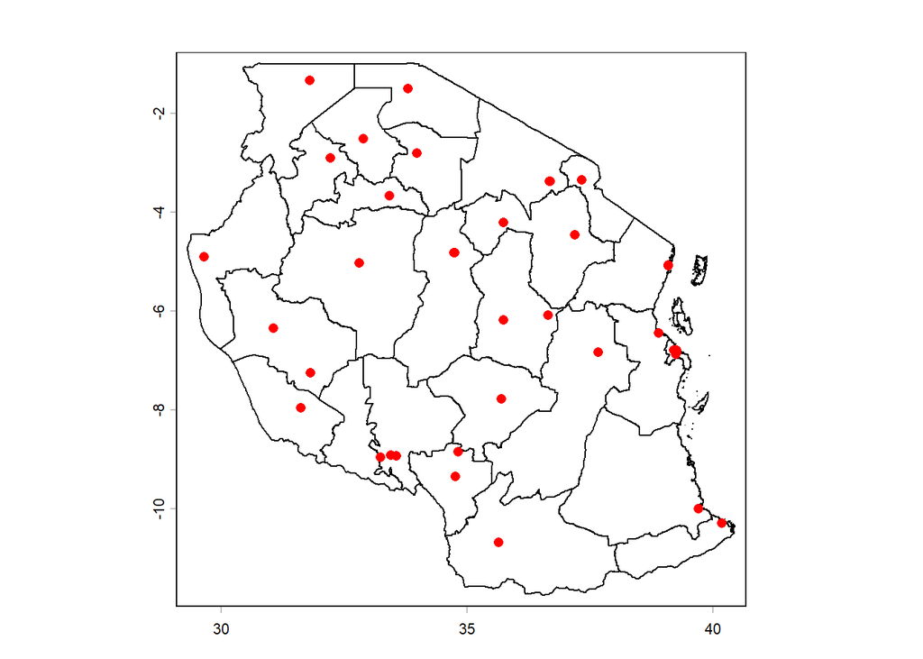

```r
# convert prices observations to vector for mapping
mypts <- vect(prices.monthly.long, geom=c("Longitude", "Latitude"), crs=crs(tza0), keepgeom=TRUE)

# see if these show up correctly
plot(tza1)
plot(mypts, col="Red", add=TRUE)
```

```r
# text(mypts, label="Market")
```

```r
# Extract Region information from GADM
region_info <- terra::extract(tza1, mypts)
# head(region_info)

# merge district names to the dataset
prices.monthly.long$Region_GADM <- region_info$NAME_1
prices.monthly.long$District_GADM <- region_info$NAME_2
```

```r
# head(prices.monthly.long)
# unique(prices.monthly.long[, c("Region", "Market", "Region_GADM")])

# Check if Region matches Region_GADM
prices.monthly.long$region_match <- prices.monthly.long$Region == prices.monthly.long$Region_GADM
# table(prices.monthly.long$region_match)

# Show mismatched rows
mis <- subset(prices.monthly.long, region_match == FALSE)
# unique(mis[, c("Region", "Market", "Region_GADM")])

# Songwe is mismatched, rename correctly
prices.monthly.long[Region_GADM == "Mbeya" & Region == "Songwe", Region_GADM := "Songwe"]
# unique(prices.monthly.long[, c("Region", "Market", "Region_GADM")])

# Check if Region matches Region_GADM
prices.monthly.long$region_match <- prices.monthly.long$Region == prices.monthly.long$Region_GADM
# table(prices.monthly.long$region_match)

# convert prices observations to vector for mapping
mypts <- vect(prices.monthly.long, geom=c("Longitude", "Latitude"), crs=crs(tza0), keepgeom=TRUE)
mkt_pts <- unique(mypts[, c("Market", "Latitude", "Longitude")])
# head(mkt_pts)
```

```r
# create reference raster
tza_extent <- ext(tza1) |> floor()
r <- crop(rast(res=1/12), tza_extent)
```

### Interpolate

```r
## Interpolate

#xy <- as.matrix(mypts[,c("Longitude", "Latitude")])
xy <- geom(mypts)[,c("y","x")]
#tps <- Tps(xy, p$spatial)
tps <- Tps(xy, mypts$pkg)
sp <- interpolate(r, tps)
sp <- mask(sp, tza1)
# plot(sp)
# lines(tza1)
```

### Predict maize prices with coodinates only

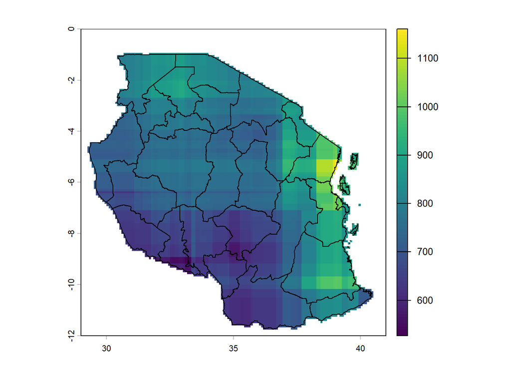

```r
## Predict Maize prices with coodinates only
maize_mypts <- mypts[mypts$Crop == "Maize", ]
rf <- randomForest(pkg ~ Longitude + Latitude , data=maize_mypts)
sp3 <- interpolate(r, rf, xyNames=c("Longitude", "Latitude"))
sp3 <- mask(sp3, tza1)
plot(sp3)
lines(tza1)
```

## Covariates

The covariates used include a mix of crop-specific indicators, temporal variables to capture monthly and yearly effects, geographical coordinates, accessibility measures, climatic conditions, and lagged rainfall to account for delayed effects of weather on crop prices.

```r
ttcity <- rast("C:/H/Tanzania Price data/Datasets/geodata/TRUE/travel/travel_time_to_cities_u5.tif")
ttport <- rast("C:/H/Tanzania Price data/Datasets/geodata/TRUE/travel/travel_time_to_ports_1.tif")
clm    <- rast("C:/H/Tanzania Price data/Datasets/geodata/TRUE/wc2.1_country/TZA_wc2.1_30s_bio.tif")
area   <- rast("C:/H/Tanzania Price data/Datasets/geodata/TRUE/spam/spam2017V2r1_SSA_H_MAIZ_A.tif")
yield  <- rast("C:/H/Tanzania Price data/Datasets/geodata/TRUE/spam/spam2017V2r1_SSA_Y_MAIZ_R.tif")
popd  <- rast("gpw_v4_population_density_rev11_2020_10m.tif")
```

```r
names(ttcity) <- c("ttcity_u5") ## travel time cities of 100k or more
names(ttport) <- c("ttport_1") ## travel time to major ports
names(clm) <- gsub("wc2.1_30s_", "", names(clm))
names(area) <- c("MAI_ARE") # SPAM maize area 2010
names(yield)  <- c("MAI_YLD") # SPAM maize yield 2010
names(popd)  <- c("popdens") # GPW4

comment(ttcity) <- "travel time to cities 100k or more"
comment(ttport) <- "travel time to major ports"

comment(popd) <- "population density 2020 (GPW4 @ 10dm)"

comment(clm)[1] <-"BIO1 = Annual Mean Temperature"
comment(clm)[2] <-"BIO2 = Mean Diurnal Range (Mean of monthly (max temp - min temp))"
comment(clm)[3] <-"BIO3 = Isothermality (BIO2/BIO7) (×100)"
comment(clm)[4] <-"BIO4 = Temperature Seasonality (standard deviation ×100)"
comment(clm)[5] <-"BIO5 = Max Temperature of Warmest Month"
comment(clm)[6] <-"BIO6 = Min Temperature of Coldest Month"
comment(clm)[7] <-"BIO7 = Temperature Annual Range (BIO5-BIO6)"
comment(clm)[8] <-"BIO8 = Mean Temperature of Wettest Quarter"
comment(clm)[9] <-"BIO9 = Mean Temperature of Driest Quarter"
comment(clm)[10] <-"BIO10 = Mean Temperature of Warmest Quarter"
comment(clm)[11] <-"BIO11 = Mean Temperature of Coldest Quarter"
comment(clm)[12] <-"BIO12 = Annual Precipitation"
comment(clm)[13] <-"BIO13 = Precipitation of Wettest Month"
comment(clm)[14] <-"BIO14 = Precipitation of Driest Month"
comment(clm)[15] <-"BIO15 = Precipitation Seasonality (Coefficient of Variation)"
comment(clm)[16] <-"BIO16 = Precipitation of Wettest Quarter"
comment(clm)[17] <-"BIO17 = Precipitation of Driest Quarter"
comment(clm)[18] <-"BIO18 = Precipitation of Warmest Quarter"
comment(clm)[19] <-"BIO19 = Precipitation of Coldest Quarter"
```

Harmonize rasters to national boundaries and common resolution

```r
ttcity <- resample(ttcity, r)
ttport <- resample(ttport, r)
clm    <- resample(clm, r)
area   <- resample(area, r)
popd   <- resample(popd, r)
freq(is.na(area))
```

```
##   layer value count
## 1     1     0 14393
## 2     1     1  6343
```

```r
area <- classify(area, cbind(NA,0))
yield  <- resample(yield, r)
freq(is.na(yield))
```

```
##   layer value count
## 1     1     0 14393
## 2     1     1  6343
```

```r
yield <- classify(yield, cbind(NA,0))
# check again
compareGeom(ttcity, ttport, clm, area, yield, popd)
```

```
## [1] TRUE
```

```r
## Generate Latitude and Longitude grid
latgrd <- longrd <- r
latgrd[] <- yFromCell(latgrd, 1:ncell(latgrd))
longrd[] <- xFromCell(longrd, 1:ncell(longrd))
names(latgrd) <- c("latitude")
names(longrd) <- c("longitude")
```

```r
# Convert water polygons to a raster mask
# We will mask out water bodies from our spatiotemporal predictions, as we are only interested in land areas where prices are relevant.
watertz <- terra::vect("Water_Supply_Control-Rivers.shp")
#watertz
water_rast <- rasterize(watertz, r, field = 1, background = 0)
```

Prepare Predictor Stack.

```r
rstack <- c(ttcity, ttport, clm, area, yield, popd, latgrd, longrd)
names(rstack)
```

```
##  [1] "ttcity_u5" "ttport_1"  "bio_1"     "bio_2"     "bio_3"     "bio_4"
##  [7] "bio_5"     "bio_6"     "bio_7"     "bio_8"     "bio_9"     "bio_10"
## [13] "bio_11"    "bio_12"    "bio_13"    "bio_14"    "bio_15"    "bio_16"
## [19] "bio_17"    "bio_18"    "bio_19"    "MAI_ARE"   "MAI_YLD"   "popdens"
## [25] "latitude"  "longitude"
```

```r
# create focal mean to extract from (as alternative to using buffers for extraction, which are not supported in terra)
fm <- focalMat(r, d=0.18, type='circle', fillNA=FALSE)
rstack2 <- focal(rstack, w=fm, fun="mean", na.policy="all", fillvalue=NA, # na.rm=TRUE,
                 expand=TRUE, silent=FALSE) #, filename="", overwrite=FALSE)
```

```r
# extract values to dataset -- use a 20km buffer
# do a focal sum of 20km radius  - this is about 0.18 of a decimal degree... 0.18*112=20.16
fm <- focalMat(r, d=0.18, type='circle', fillNA=FALSE)
rstack2 <- focal(rstack2, w=fm, fun="sum", na.policy="all", fillvalue=NA, na.rm=TRUE,
                 expand=TRUE, silent=FALSE) #, filename="", overwrite=FALSE)
```

#### Lag rainfall

```r
## Bring in Rainfall Data from Chirps
chirps_path <- "C:/H/Tanzania Price data/chirps_data"

chirps_files <- list.files(chirps_path, pattern = ".tif$", full.names = TRUE)

# Read all CHIRPS data files into a SpatRaster collection
chirps_rasters <- rast(chirps_files)

#crop to Tanzania boundary
Chirps_Tz <- crop(chirps_rasters, tza1)

writeRaster(Chirps_Tz, "Tz_chirps_monthly_croped.tif", overwrite=TRUE)

Tz_chirps_monthly <- terra::rast("Tz_chirps_monthly_croped.tif")
Tz_chirps_monthly
```

```
## class       : SpatRaster
## size        : 215, 222, 63  (nrow, ncol, nlyr)
## resolution  : 0.05, 0.05  (x, y)
## extent      : 29.35, 40.45, -11.75, -1.000001  (xmin, xmax, ymin, ymax)
## coord. ref. : lon/lat WGS 84 (EPSG:4326)
## source      : Tz_chirps_monthly_croped.tif
## names       : chirp~20.11, chirp~20.12, chirp~21.01, chirp~21.02, chirp~21.03, chirp~21.04, ...
## min values  :  -9999.0000,  -9999.0000,   -9999.000,  -9999.0000,  -9999.0000,  -9999.0000, ...
## max values  :    459.7112,    504.3329,     508.448,    585.3241,    750.1949,    960.3376, ...
```

```r
#Replace -9999 with NA
Tz_chirps_monthly <- classify(Tz_chirps_monthly, cbind(-9999,NA))

#extract layer names
layer_names <- names(Tz_chirps_monthly)
# layer_names

# We need to create a sequence of dates from the layer names
# Extract year and month from layer names and convert to Date
dates <- as.Date(paste0(sub("chirps-v2.0\\.", "", layer_names), "-01"), format = "%Y.%m-%d")
# dates

# Assign these dates to the SpatRaster object
time(Tz_chirps_monthly) <- dates

#rename the layers to the formatted dates
names(Tz_chirps_monthly) <- dates

# Check the SpatRaster object
print(Tz_chirps_monthly)
```

```
## class       : SpatRaster
## size        : 215, 222, 63  (nrow, ncol, nlyr)
## resolution  : 0.05, 0.05  (x, y)
## extent      : 29.35, 40.45, -11.75, -1.000001  (xmin, xmax, ymin, ymax)
## coord. ref. : lon/lat WGS 84 (EPSG:4326)
## source(s)   : memory
## varname     : Tz_chirps_monthly_croped
## names       : 2020-11-01, 2020-12-01,  2021-01-01,  2021-02-01,  2021-03-01, 2021-04-01, ...
## min values  :   5.859746,   1.903993,   0.8161677,   0.3187093,   0.9539621,    1.17571, ...
## max values  : 459.711212, 504.332947, 508.4479980, 585.3240967, 750.1949463,  960.33765, ...
## time (days) : 2020-11-01 to 2026-01-01 (63 steps)
```

```r
# do a focal mean of 100km radius - this is about 0.9 of a decimal degree... 0.9009*112=100.9008
# Calculate the focal mean for each layer (month)
fm_r <- focalMat(Tz_chirps_monthly, d=0.9, type='circle', fillNA=FALSE)
Rainfall_focal_sum_100km <- focal(Tz_chirps_monthly, w=fm_r, fun="mean", na.policy="all", fillvalue=NA, na.rm=TRUE,
                                  expand=TRUE, silent=FALSE)
# Check the result
Rainfall_focal_sum_100km
```

```
## class       : SpatRaster
## size        : 215, 222, 63  (nrow, ncol, nlyr)
## resolution  : 0.05, 0.05  (x, y)
## extent      : 29.35, 40.45, -11.75, -1.000001  (xmin, xmax, ymin, ymax)
## coord. ref. : lon/lat WGS 84 (EPSG:4326)
## source(s)   : memory
## varname     : Tz_chirps_monthly_croped
## names       : 2020-11-01, 2020-12-01, 2021-01-01, 2021-02-01, 2021-03-01, 2021-04-01, ...
## min values  :   20.79649,   27.27837,   8.092316,   4.489223,   11.30184,   15.74836, ...
## max values  :  313.14248,  326.88227, 416.590468, 395.422070,  464.67840,  569.81990, ...
## time (days) : 2020-11-01 to 2026-01-01 (63 steps)
```

```r
Rainfall <- Rainfall_focal_sum_100km
```

```r
#Resample
Rainfall_res <- resample(Rainfall, r)
Rainfall_res
```

```
## class       : SpatRaster
## size        : 144, 144, 63  (nrow, ncol, nlyr)
## resolution  : 0.08333333, 0.08333333  (x, y)
## extent      : 29, 41, -12, 0  (xmin, xmax, ymin, ymax)
## coord. ref. : lon/lat WGS 84 (EPSG:4326)
## source(s)   : memory
## names       : 2020-11-01, 2020-12-01, 2021-01-01, 2021-02-01, 2021-03-01, 2021-04-01, ...
## min values  :   20.89972,    32.9472,   8.116516,   4.527868,   11.83634,   15.90436, ...
## max values  :  310.41034,   326.4339, 416.389160, 395.367279,  462.19266,  550.26270, ...
## time (days) : 2020-11-01 to 2026-01-01 (63 steps)
```

Here we define function that calculates 6 month lag sum of rainfall for each month in our data. The output is raster datsets.

```r
calculate_lagged_sum <- function(raster_stack, num_months = 6) {
  # Get the time vector from the raster stack
  time_vector <- time(raster_stack)

  # Initialize list to store lagged sum rasters
  lagged_sum_rasters <- vector("list", length(time_vector))

  # Loop through each layer in the raster stack
  for (i in seq_along(time_vector)) {
    if (i > num_months) {  # We need at least 'num_months' previous layers to calculate the lagged sum
      # Determine the start and end dates for the lag period
      end_date <- time_vector[i] # Date of the current layer being processed
      start_date <- end_date %m-% months(num_months) #The date num_months before the end_date

      # Select the layers that fall within the lag period
      lag_period_layers <- raster_stack[[which(time_vector > start_date & time_vector <= end_date)]]

      # Calculate the sum of the selected layers
      if (nlyr(lag_period_layers) == num_months) {
        lagged_sum_rasters[[i]] <- sum(lag_period_layers, na.rm = TRUE)
      } else {
        lagged_sum_rasters[[i]] <- rast(nrow = nrow(raster_stack), ncol = ncol(raster_stack),
                                        crs = crs(raster_stack), ext = ext(raster_stack),
                                        vals = NA)  # Use an empty raster with NA values
      }
    } else {
      lagged_sum_rasters[[i]] <- rast(nrow = nrow(raster_stack), ncol = ncol(raster_stack),
                                      crs = crs(raster_stack), ext = ext(raster_stack),
                                      vals = NA)  # Use an empty raster with NA values
    }
  }

  # Combine the lagged sum rasters into a single raster stack, excluding empty rasters
  lagged_sum_stack <- rast(lagged_sum_rasters)

  # Set the names for the layers in the lagged sum stack
  names(lagged_sum_stack) <- names(raster_stack)[!is.na(lagged_sum_rasters)]

  return(lagged_sum_stack)
}

# Calculate the 6-month lagged sum for each period in the raster stack
lagged_rainfall_sum <- calculate_lagged_sum(Rainfall_res, num_months = 6)

# Remove the first 6 layers from the raster stack since they are empty
lagged_rainfall_sum_filtered <- lagged_rainfall_sum[[7:nlyr(lagged_rainfall_sum)]]
# check the result
print(lagged_rainfall_sum_filtered)
```

```
## class       : SpatRaster
## size        : 144, 144, 57  (nrow, ncol, nlyr)
## resolution  : 0.08333333, 0.08333333  (x, y)
## extent      : 29, 41, -12, 0  (xmin, xmax, ymin, ymax)
## coord. ref. : lon/lat WGS 84 (EPSG:4326)
## source(s)   : memory
## names       : 2021-05-01, 2021-06-01, 2021-07-01, 2021-08-01, 2021-09-01, 2021-10-01, ...
## min values  :   172.7856,   105.5447,   105.4121,   105.1864,   26.20571,   7.070483, ...
## max values  :  1512.4689,  1355.9669,  1052.9220,  1051.9214, 1038.13874, 643.716021, ...
```

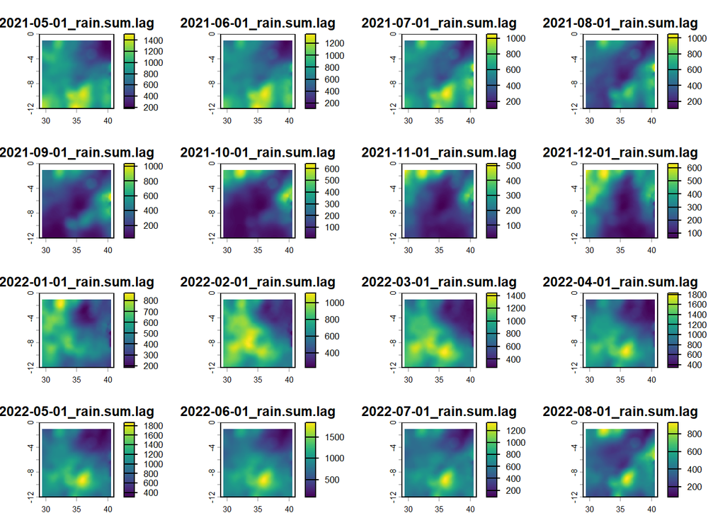

```r
names(lagged_rainfall_sum_filtered) <- paste0(names(lagged_rainfall_sum_filtered), "_rain.sum.lag")

plot(lagged_rainfall_sum_filtered)
```

```r
## We'll have to include lagged_rainfall_sum_filtered in the predictor stack.
rstack
```

```
## class       : SpatRaster
## size        : 144, 144, 26  (nrow, ncol, nlyr)
## resolution  : 0.08333333, 0.08333333  (x, y)
## extent      : 29, 41, -12, 0  (xmin, xmax, ymin, ymax)
## coord. ref. : lon/lat WGS 84 (EPSG:4326)
## source(s)   : memory
## names       :    ttcity_u5,  ttport_1,     bio_1,     bio_2,    bio_3,     bio_4, ...
## min values  : 3.350081e-02,  997.9427,  4.333545,  6.546645, 53.85881,  19.75255, ...
## max values  : 1.166560e+03, 3043.3459, 28.472235, 15.285786, 93.14099, 266.33594, ...
```

```r
#names(rstack)
```

```r
rstack3 <- c(rstack, lagged_rainfall_sum_filtered)
# names(rstack3)
```

```r
#Extract to the point dataset
extr1 <- terra::extract(rstack3, mypts, method = "bilinear")
mypts <- cbind(mypts, extr1)
# Remove the ID column from the dataset
mypts <- mypts[, !names(mypts) %in% "ID"]
```

Here we extract sum of lag rainfall for each row under the column rain.sum.lag

```r
mypts_df <- as.data.frame(mypts)

# Define the function to obtain sum of lag rainfall from corresponding rasters to mypts under rain.sum.lag column (for each row)
# Each extraction has to match the month and year
get_rain_sum_row <- function(current_date, mypts_row) {
  # Extract the rainfall value for the current date
  rain_sum <- mypts_row[[paste0(current_date, "_rain.sum.lag")]]
  return(rain_sum)
}

# Loop through each row and obtain the rainfall sum for each month and year
for (i in 1:nrow(mypts_df)) {
  # Extract relevant data for the current row
  month <- mypts_df$Month[i]
  year <- mypts_df$Year[i]
  current_date <- paste0(year, "-", sprintf("%02d", month), "-01")  # Format date correctly
  # Pass necessary data to the function
  rain_sum <- get_rain_sum_row(current_date, mypts_df[i, ])
  # Update the rain.sum.lag column
  mypts_df$rain.sum.lag[i] <- rain_sum
}

# Update the SpatVector with the new rain.avg column
mypts$rain.sum.lag <- mypts_df$rain.sum.lag
```

```r
# I'll drop the dates with rain.sum.lag from mypts, seems redundant
column_indices <- grep("^202[0-4]-", names(mypts))
mypts <- mypts[, -column_indices]
# names(mypts)
```

```r
#define Month as a factor
# mypts$Month <- as.factor(mypts$Month)
# levels(mypts$Month)

# We'll define month as an interger instead.
# Check to make sure Month is interger
# sapply(mypts, class)
```

```r
# drop levels that don't exist in Crop field
mypts$Crop <- mypts$Crop[,drop=TRUE]
levels(mypts$Crop)
```

```
## [1] "Maize"    "Rice"     "Sorghum"  "B.Millet" "F.Millet" "Wheat"    "Beans"
## [8] "Potato"
```

# Linear model

Coefficient estimates from the linear model provide insights into the relationship between each predictor and the price variable.

```r
# Fit the linear model
# Linear model price Prediction
# Fit the linear model
lm_model <- lm(pkg_real ~ maize + rice + sorghum + bmillet + fmillet + wheat + CPI + beans + Month + Year + ttcity_u5 + ttport_1 + bio_1 + bio_2 + bio_3 + bio_4 + bio_5 + bio_6 +  bio_7 + bio_8 + bio_9 + bio_10 + bio_11 + bio_12 + bio_13 + bio_14 + bio_15 + bio_16 + bio_17 + bio_18 + bio_19 + Longitude + Latitude +
                 rain.sum.lag,
               data = mypts)
# Extract and print the coefficients
summary(lm_model)
```

```
##
## Call:
## lm(formula = pkg_real ~ maize + rice + sorghum + bmillet + fmillet +
##     wheat + CPI + beans + Month + Year + ttcity_u5 + ttport_1 +
##     bio_1 + bio_2 + bio_3 + bio_4 + bio_5 + bio_6 + bio_7 + bio_8 +
##     bio_9 + bio_10 + bio_11 + bio_12 + bio_13 + bio_14 + bio_15 +
##     bio_16 + bio_17 + bio_18 + bio_19 + Longitude + Latitude +
##     rain.sum.lag, data = mypts)
##
## Residuals:
##      Min       1Q   Median       3Q      Max
## -1319.04  -244.99   -18.95   224.41  2085.82
##
## Coefficients: (1 not defined because of singularities)
##                Estimate Std. Error t value Pr(>|t|)
## (Intercept)   1.009e+06  5.962e+04  16.928  < 2e-16 ***
## maize        -9.182e+01  1.449e+01  -6.335 2.48e-10 ***
## rice          1.259e+03  1.445e+01  87.167  < 2e-16 ***
## sorghum       3.915e+02  1.508e+01  25.955  < 2e-16 ***
## bmillet       5.023e+02  1.586e+01  31.660  < 2e-16 ***
## fmillet       8.948e+02  1.493e+01  59.934  < 2e-16 ***
## wheat         8.676e+02  1.605e+01  54.050  < 2e-16 ***
## CPI           1.486e+02  7.709e+00  19.271  < 2e-16 ***
## beans         1.483e+03  1.447e+01 102.511  < 2e-16 ***
## Month        -3.944e+01  2.384e+00 -16.545  < 2e-16 ***
## Year         -5.117e+02  2.985e+01 -17.141  < 2e-16 ***
## ttcity_u5     6.182e-01  1.130e-01   5.472 4.55e-08 ***
## ttport_1     -6.328e-01  1.270e-01  -4.981 6.44e-07 ***
## bio_1        -1.192e+03  1.356e+02  -8.789  < 2e-16 ***
## bio_2        -8.839e+02  1.045e+02  -8.459  < 2e-16 ***
## bio_3         1.262e+02  1.137e+01  11.100  < 2e-16 ***
## bio_4        -3.757e+00  2.674e+00  -1.405  0.15999
## bio_5         5.990e+02  8.216e+01   7.291 3.31e-13 ***
## bio_6        -6.711e+02  7.261e+01  -9.243  < 2e-16 ***
## bio_7                NA         NA      NA       NA
## bio_8         4.627e+02  4.946e+01   9.355  < 2e-16 ***
## bio_9        -2.212e+02  4.758e+01  -4.648 3.39e-06 ***
## bio_10        3.154e+02  1.004e+02   3.140  0.00170 **
## bio_11        7.078e+02  1.560e+02   4.537 5.77e-06 ***
## bio_12        8.438e-01  1.986e-01   4.248 2.17e-05 ***
## bio_13        3.994e+00  6.377e-01   6.263 3.93e-10 ***
## bio_14       -3.515e+01  6.237e+00  -5.635 1.80e-08 ***
## bio_15        3.345e+00  1.448e+00   2.311  0.02086 *
## bio_16       -1.205e+00  3.332e-01  -3.617  0.00030 ***
## bio_17        3.775e+00  2.064e+00   1.829  0.06737 .
## bio_18       -1.464e+00  1.492e-01  -9.808  < 2e-16 ***
## bio_19        2.170e+00  1.783e+00   1.217  0.22360
## Longitude     5.839e+01  1.245e+01   4.691 2.75e-06 ***
## Latitude     -4.602e+01  1.401e+01  -3.286  0.00102 **
## rain.sum.lag -2.924e-01  1.851e-02 -15.793  < 2e-16 ***
## ---
## Signif. codes:  0 '***' 0.001 '**' 0.01 '*' 0.05 '.' 0.1 ' ' 1
##
## Residual standard error: 380.7 on 9993 degrees of freedom
## Multiple R-squared:  0.7007, Adjusted R-squared:  0.6997
## F-statistic: 709.1 on 33 and 9993 DF,  p-value: < 2.2e-16
```

# RandomForest

### Split data the to be used for Training and validation

Data from May 2021 - Dec 2024 will be used for model training while more recent data from Jan 2025 - Jan 2026 will be used for Validation.

```r
mypts <- as.data.table(mypts)
mypts$Month <- as.integer(as.character(mypts$Month))

training_data <- mypts[mypts$Year %in% c(2021, 2022, 2023, 2024), ]
training_data <- as.data.frame(training_data)
```

```r
# Filter the data for validation (Jan 2025 - Jan 2026)
validation_data <- mypts[mypts$Year %in% c(2025, 2026), ]
validation_data <- as.data.frame(validation_data)
```

### Fit The Random Forest Model (1)

#### Random Forest for generating variable of importance

Here, the model is fitted using the randomForest function to build a predictive model for food commodity prices. The goal is to generate Variable importance scores which will help us understand which variables have the most significant impact on prices, enabling us to interpret the model and possibly simplify it by focusing on the most important predictors.

```r
# Create the random forest model
rf1 <- randomForest(pkg_real ~ maize + rice + sorghum + bmillet + fmillet + wheat + beans + potato + Month + Year + CPI + popdens +
                      ttcity_u5 + ttport_1 +
                      bio_1 + bio_2 + bio_3 + bio_4 + bio_5 + bio_6 +
                      bio_7 + bio_8 + bio_9 + bio_10 + bio_11 + bio_12 +
                      bio_13 + bio_14 + bio_15 + bio_16 + bio_17 +
                      bio_18 + bio_19 + MAI_ARE + MAI_YLD +
                      Longitude + Latitude +
                      rain.sum.lag,
                    data = training_data,
                    importance=TRUE,na.rm=TRUE)

rf1
```

```
##
## Call:
##  randomForest(formula = pkg_real ~ maize + rice + sorghum + bmillet +      fmillet + wheat + beans + potato + Month + Year + CPI + popdens +      ttcity_u5 + ttport_1 + bio_1 + bio_2 + bio_3 + bio_4 + bio_5 +      bio_6 + bio_7 + bio_8 + bio_9 + bio_10 + bio_11 + bio_12 +      bio_13 + bio_14 + b…
##                Type of random forest: regression
##                      Number of trees: 500
## No. of variables tried at each split: 12
##
##           Mean of squared residuals: 28812.25
##                     % Var explained: 93.77
```

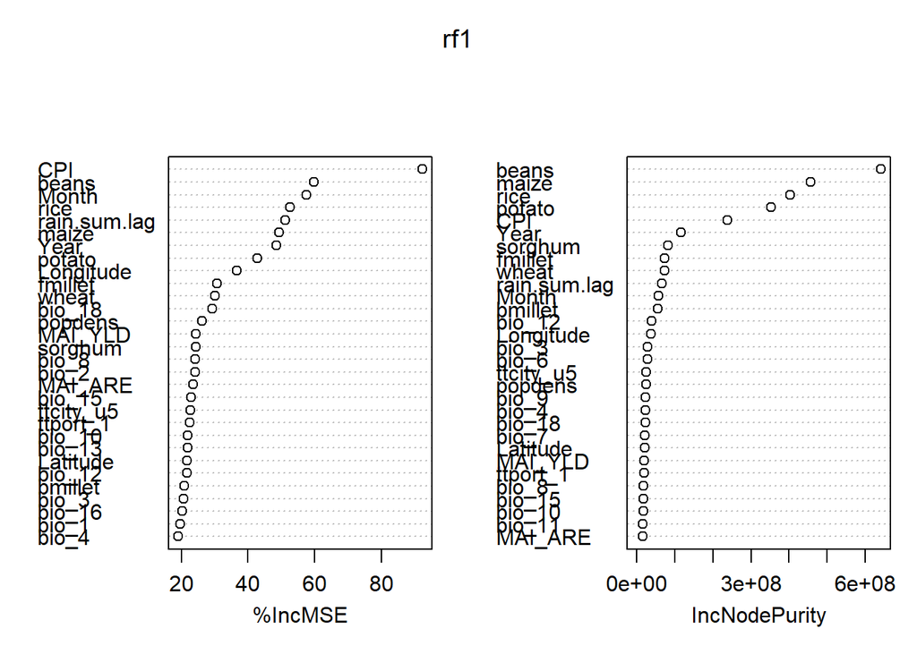

```r
varImpPlot(rf1)
```

```r
importance_metrics <- importance(rf1, type=1)  # %IncMSE
impvar <- rownames(importance_metrics)[order(importance_metrics[, 1], decreasing=TRUE)]
# Get the top 20 variables
top_20_vars <- impvar[1:20]
top_20_vars
```

```
##  [1] "CPI"          "beans"        "Month"        "rice"         "rain.sum.lag"
##  [6] "maize"        "Year"         "potato"       "Longitude"    "fmillet"
## [11] "wheat"        "bio_18"       "popdens"      "MAI_YLD"      "sorghum"
## [16] "bio_8"        "bio_2"        "MAI_ARE"      "bio_15"       "ttcity_u5"
```

```r
node_purity <- importance(rf1, type=2)  # IncNodePurity
# Sort variables by importance (IncNodePurity)
node_purity_sorted <- sort(node_purity[,1], decreasing = TRUE)
# Select the top 20 important variables
top_vars <- names(node_purity_sorted)[1:20]
print(top_vars)
```

```
##  [1] "beans"        "maize"        "rice"         "potato"       "CPI"
##  [6] "Year"         "sorghum"      "fmillet"      "wheat"        "rain.sum.lag"
## [11] "Month"        "bmillet"      "bio_12"       "Longitude"    "bio_3"
## [16] "bio_6"        "ttcity_u5"    "popdens"      "bio_9"        "bio_4"
```

```r
rf1$importanceSD
```

```
##        maize         rice      sorghum      bmillet      fmillet        wheat
##    3454.4714    3293.8631    1563.4950    1100.6423     968.3320     930.5833
##        beans       potato        Month         Year          CPI      popdens
##    4007.9917    3073.8505     223.9765    1034.2253     939.6915     423.5485
##    ttcity_u5     ttport_1        bio_1        bio_2        bio_3        bio_4
##     554.1811     409.6006     466.9160     310.6922     846.7197     722.6734
##        bio_5        bio_6        bio_7        bio_8        bio_9       bio_10
##     432.8333    1170.1633     778.9814     405.2678    1248.1884     440.9908
##       bio_11       bio_12       bio_13       bio_14       bio_15       bio_16
##     627.0624    1325.3268     291.3089     593.2058     466.2249     344.9848
##       bio_17       bio_18       bio_19      MAI_ARE      MAI_YLD    Longitude
##     836.6606     378.0573     366.0563     340.8716     457.8658     482.0589
##     Latitude rain.sum.lag
##     518.5136     241.3220
```

### Fit The Random Forest Model (2)

#### 1. Tune The Forest

We use the tuneRF function to iteratively search for the optimal mtry value that minimizes the Out-of-Bag (OOB) error. In the random forest model, we will use this mtry value.

```r
predictors_pooled <- c("maize", "rice", "sorghum", "bmillet", "fmillet", "wheat", "beans", "potato", "Month", "Year", "CPI", "ttport_1", "ttcity_u5", "popdens", "bio_3", "bio_6", "bio_9", "bio_12", "bio_18", "rain.sum.lag")

trf <- tuneRF(x = training_data[, predictors_pooled],
              y = training_data$pkg_real,
              stepFactor = 1.5, improve = 0.01, ntreeTry = 500, plot = FALSE, trace = TRUE)
```

```
## mtry = 6  OOB error = 28882.33
## Searching left ...
## mtry = 4     OOB error = 34825.41
## -0.2057687 0.01
## Searching right ...
## mtry = 9     OOB error = 27512.78
## 0.04741823 0.01
## mtry = 13    OOB error = 27469.34
## 0.00157893 0.01
```

```r
best_mtry <- trf[which.min(trf[, 2]), 1]
```

#### 2. Estimate more parsimonious model

Here we fit a more parsimonous model by using the most important predictor variables identified above. This model will be used for spatial-temporal prediction.

```r
### Fit The Random Forest Model (2)
rf <- randomForest(pkg_real ~ maize + rice + sorghum + bmillet + fmillet + wheat + beans + potato + Month + Year + CPI + ttport_1 + ttcity_u5 + popdens + bio_3 + bio_6 + bio_9 + bio_12 + bio_18 + rain.sum.lag,
                   data = training_data,
                   mtry = best_mtry,
                   ntree = 1000,
                   nodesize = 5,
                   importance = TRUE,
                   na.action = na.omit)
rf
```

```
##
## Call:
##  randomForest(formula = pkg_real ~ maize + rice + sorghum + bmillet +      fmillet + wheat + beans + potato + Month + Year + CPI + ttport_1 +      ttcity_u5 + popdens + bio_3 + bio_6 + bio_9 + bio_12 + bio_18 +      rain.sum.lag, data = training_data, mtry = best_mtry, ntree = 1000,      nodesize…
##                Type of random forest: regression
##                      Number of trees: 1000
## No. of variables tried at each split: 13
##
##           Mean of squared residuals: 27341.81
##                     % Var explained: 94.09
```

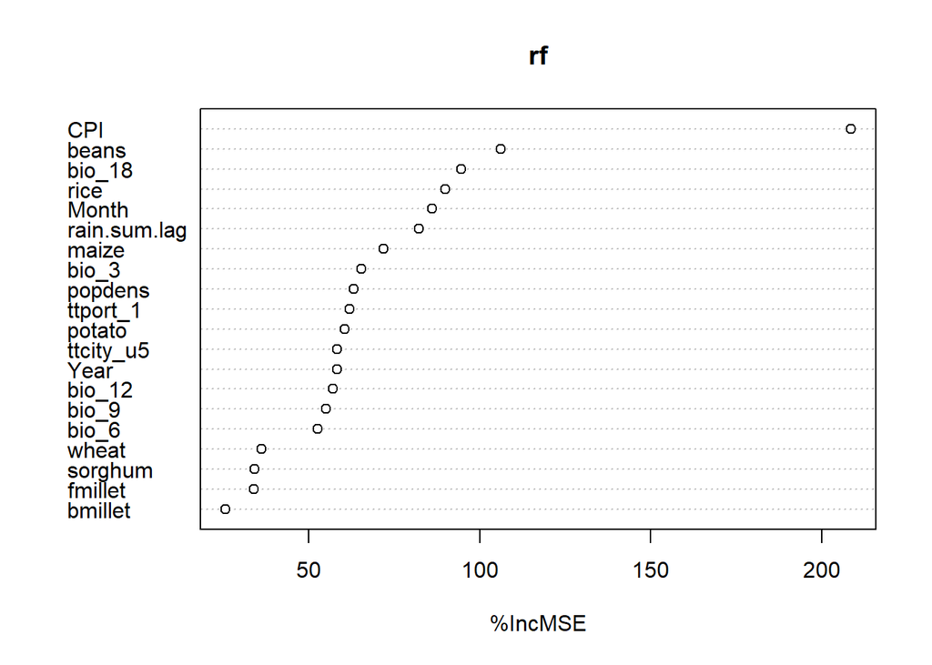

```r
# Plotting %IncMSE variable importance plot
varImpPlot(rf, type = 1)
```

```r
(oob <- sqrt(rf$mse[which.min(rf$mse)]))
```

```
## [1] 165.2346
```

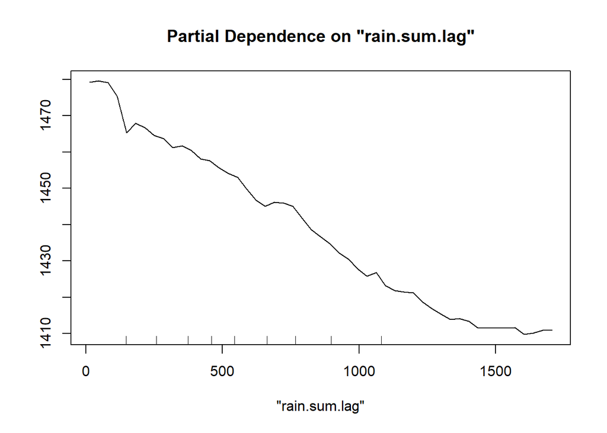

```r
partialPlot(rf, as.data.frame(training_data), "rain.sum.lag")
```

## spatial Temporal prediction

These are prediction plots for each food commodities (maize, beans, rice, sorghum, bmillet, fmillet, wheat, potato) with their respective month of the year 2025.

```r
year <- 2025
```

```r
# Create a lookup for 2025 CPI values
cpi_2025 <- data.frame(
  Month = 1:12,
  CPI_val = c(117.57, 118.28, 119.27, 119.78, 119.85, 120.18,
              119.85, 119.77, 119.86, 119.63, 120.01, 121.11))
```

Note: we must set the rain.sum.lag variables for each month we are predicting

### Predicted Maize Prices

```r
#Maize
predict_for_maize <- function(month) {
  # Get the actual NCPI for this specific month
  current_cpi <- cpi_2025$CPI_val[cpi_2025$Month == month]

  # Load rainfall lag for 2025 (ensure your stack names match this format)
  delta_rain.sum.lag <- rstack3[paste0("2025-", sprintf("%02d", month), "-01_rain.sum.lag")]
  names(delta_rain.sum.lag) <- "rain.sum.lag"

  # Prepare the predictor stack
  newstack <- c(rstack, delta_rain.sum.lag)
  watertz_proj <- project(watertz, crs(newstack))
  newstack_masked <- mask(newstack, watertz_proj, inverse = TRUE)

  # Define constant data for prediction
  const_maize <- data.frame(
    maize = 1, rice = 0, sorghum = 0, bmillet = 0, fmillet = 0,
    wheat = 0, beans = 0, potato = 0,
    Month = as.integer(month),
    #Month = factor(month, levels = levels(training_data$Month)),
    Year = 2025,
    CPI = current_cpi
  )

  # Generate prediction
  pred <- predict(newstack_masked, rf, const = const_maize, na.rm = TRUE)
  pred <- mask(pred, tza1)

  return(pred)
}

# 3. Create predictions for all months
predictions_maize <- lapply(1:12, predict_for_maize)

# Extract pixel values from predictions_maize
maize_values <- unlist(lapply(predictions_maize, values))
# Get min and max values
min_maize <- min(maize_values, na.rm = TRUE)
min_maize
```

```
## [1] 391.5342
```

```r
max_maize <- max(maize_values, na.rm = TRUE)
max_maize
```

```
## [1] 1003.622
```

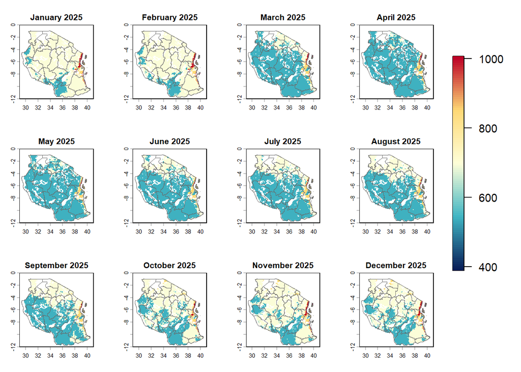

```r
# Define the continuous color palette and reverse it
# color_palette <- rev(terrain.colors(100))
#color_palette <- colorRampPalette(c("blue", "wheat", "red"))(100)
color_palette <- colorRampPalette(c("#081d58", "#41b6c4", "#ffffd9", "#fed976", "#bd0026"))(100)

# Set up plot layout with an extra column for the legend
layout_matrix <- matrix(c(1, 2, 3, 4, 13,
                          5, 6, 7, 8, 13,
                          9, 10, 11, 12, 13), nrow = 3, byrow = TRUE)

# Set up layout
layout(layout_matrix, heights = c(2, 2, 2, 0.6), widths = c(1, 1, 1, 1, 0.6))

break_interval <- 150

# Create a 3x4 matrix of plots
par(mar = c(0, 0, 0, 0))  # Set margins to 0 for inner plots
for (i in 1:12) {
  plot(predictions_maize[[i]], main = paste(month.name[i], year),
       zlim = c(min_maize, max_maize), col = color_palette, breaks = seq(min_maize, max_maize, by = break_interval), legend = FALSE, axes = TRUE, cex.main = 1.0)

  # Add region boundaries
  plot(tza1, add = TRUE, border = "dimgray", lwd = 0.1)

  #points(mkt_pts, pch = 19, col = "red", cex = 0.9)
}

# Generate pretty breaks for the legend
legend_breaks <- pretty(c(min_maize, max_maize), n = 4)

# Reset plot layout for the legend
layout(matrix(1))
par(mar = c(5, 4, 2, 4))

# Plot the legend as vertical (default orientation)
image.plot(zlim = c(min_maize, max_maize), legend.only = TRUE,
           col = color_palette,
           legend.width = 1, legend.shrink = 0.8,
           axis.args = list(at = legend_breaks, labels = legend_breaks, cex.axis = 0.9),
           legend.args = list(text = "", side = 4, line = 3.5, cex = 0.8))
```

```r
output_dir_Maize <- "C:/H/Tanzania Price data/Datasets/Pred-plots/Maize"

for (i in 1:length(predictions_maize)) {
  month_str <- sprintf("%02d", i)
  output_filename <- paste0("maize_price_rf_pred_", month_str, ".tif")
  output_path <- file.path(output_dir_Maize, output_filename)
  writeRaster(predictions_maize[[i]], output_path, overwrite = TRUE)
}
```

### Predicted Beans Prices

```r
# Beans
# Function to predict beans for a given month
predict_for_beans <- function(month) {
  # Get the actual NCPI for this specific month
  current_cpi <- cpi_2025$CPI_val[cpi_2025$Month == month]

  # Load rainfall lag for 2025 (ensure your stack names match this format)
  delta_rain.sum.lag <- rstack3[paste0("2025-", sprintf("%02d", month), "-01_rain.sum.lag")]
  names(delta_rain.sum.lag) <- "rain.sum.lag"

  # Prepare the predictor stack
  newstack <- c(rstack, delta_rain.sum.lag)
  watertz_proj <- project(watertz, crs(newstack))
  newstack_masked <- mask(newstack, watertz_proj, inverse = TRUE)

  # Define constant data for prediction
  const_maize <- data.frame(
    maize = 0, rice = 0, sorghum = 0, bmillet = 0, fmillet = 0,
    wheat = 0, beans = 1, potato = 0,
    #Month = factor(month, levels = levels(training_data$Month)),
    Month = as.integer(month),
    Year = 2025,
    CPI = current_cpi
  )

  # Generate prediction
  pred <- predict(newstack_masked, rf, const = const_maize, na.rm = TRUE)
  pred <- mask(pred, tza1)

  return(pred)
}
# Create predictions for all months
predictions_beans <- lapply(1:12, predict_for_beans)

# Extract pixel values from predictions_beans
bean_values <- unlist(lapply(predictions_beans, values))
min_bean <- min(bean_values, na.rm = TRUE)
min_bean
```

```
## [1] 1606.934
```

```r
max_bean <- max(bean_values, na.rm = TRUE)
max_bean
```

```
## [1] 3100.709
```

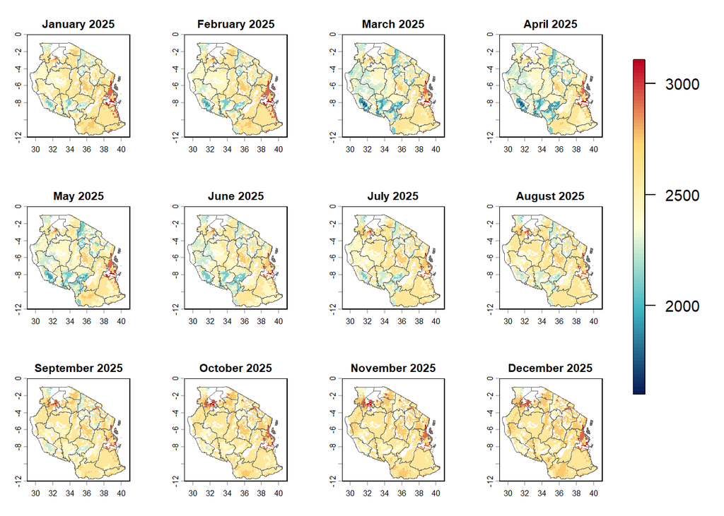

```r
# Define the continuous color palette and reverse it
#color_palette <- rev(terrain.colors(100))
# color_palette <- colorRampPalette(c("blue", "wheat", "red"))(100)
color_palette <- colorRampPalette(c("#081d58", "#41b6c4", "#ffffd9", "#fed976", "#bd0026"))(100)


# Set up plot layout with an extra row for the legend
layout_matrix <- matrix(c(1, 2, 3, 4, 13,
                          5, 6, 7, 8, 13,
                          9, 10, 11, 12, 13), nrow = 3, byrow = TRUE)

# Set up layout
layout(layout_matrix, heights = c(2, 2, 2, 0.6), widths = c(1, 1, 1, 1, 0.6))


break_interval <- 150

# Loop through each month to plot beans prices
par(mar = c(0, 0, 0, 0))
for (i in 1:12) {
  plot(predictions_beans[[i]], main = paste(month.name[i], year),
       zlim = c(min_bean, max_bean), col = color_palette, breaks = seq(min_bean, max_bean, by = break_interval), legend = FALSE, axes = TRUE, cex.main = 1.0)

  plot(tza1, add = TRUE, border = "dimgray", lwd = 0.1)

  points(training_data, pch = 20, col = "red", cex = 0.5)
}

# Generate pretty breaks for the legend
legend_breaks <- pretty(c(min_bean, max_bean), n = 4)

# Reset plot layout to 1x1 for the legend
layout(matrix(1))
par(mar = c(5, 4, 2, 4))

# Plot the legend in the bottom row, centered horizontally
image.plot(zlim = c(min_bean, max_bean), legend.only = TRUE,
           col = color_palette,
           legend.width = 0.7, legend.shrink = 0.9,
           axis.args = list(at = legend_breaks, labels = legend_breaks, cex.axis = 0.9),
           legend.args = list(text = "", side = 2, line = 2, cex = 0.9))
```

```r
output_dir_beans <- "C:/H/Tanzania Price data/Datasets/Pred-plots/beans"

for (i in 1:length(predictions_beans)) {
  month_str <- sprintf("%02d", i)
  output_filename <- paste0("beans_price_rf_pred_", month_str, ".tif")
  output_path <- file.path(output_dir_beans, output_filename)
  writeRaster(predictions_beans[[i]], output_path, overwrite = TRUE)
}
```

### Predicted Rice Prices

```r
# Rice
# Function to predict rice prices for a given month
predict_for_rice <- function(month) {
  # Get the actual NCPI for this specific month
  current_cpi <- cpi_2025$CPI_val[cpi_2025$Month == month]

  # Load rainfall lag for 2025 (ensure your stack names match this format)
  delta_rain.sum.lag <- rstack3[paste0("2025-", sprintf("%02d", month), "-01_rain.sum.lag")]
  names(delta_rain.sum.lag) <- "rain.sum.lag"

  # Prepare the predictor stack
  newstack <- c(rstack, delta_rain.sum.lag)
  watertz_proj <- project(watertz, crs(newstack))
  newstack_masked <- mask(newstack, watertz_proj, inverse = TRUE)

  # Define constant data for prediction
  const_maize <- data.frame(
    maize = 0, rice = 1, sorghum = 0, bmillet = 0, fmillet = 0,
    wheat = 0, beans = 0, potato = 0,
    # Month = factor(month, levels = levels(training_data$Month)),
    Month = as.integer(month),
    Year = 2025,
    CPI = current_cpi
  )

  # Generate prediction
  pred <- predict(newstack_masked, rf, const = const_maize, na.rm = TRUE)
  pred <- mask(pred, tza1)

  return(pred)
}

# Create predictions for all months
predictions_rice <- lapply(1:12, predict_for_rice)

# Extract pixel values from predictions_rice
rice_values <- unlist(lapply(predictions_rice, values))
min_rice <- min(rice_values, na.rm = TRUE)
min_rice
```

```
## [1] 1308.283
```

```r
max_rice <- max(rice_values, na.rm = TRUE)
max_rice
```

```
## [1] 2436.162
```

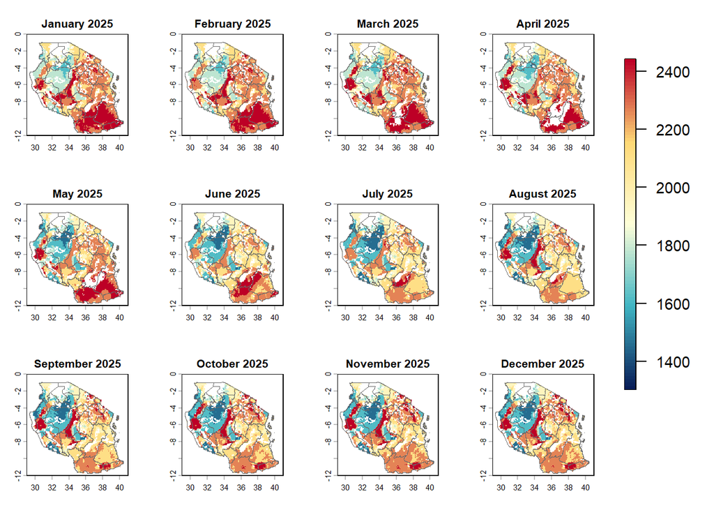

```r
# Define the continuous color palette and reverse it
# color_palette <- rev(terrain.colors(100))
#color_palette <- colorRampPalette(c("blue", "wheat", "red"))(100)
color_palette <- colorRampPalette(c("#081d58", "#41b6c4", "#ffffd9", "#fed976", "#bd0026"))(100)

layout_matrix <- matrix(c(1, 2, 3, 4, 13,
                          5, 6, 7, 8, 13,
                          9, 10, 11, 12, 13), nrow = 3, byrow = TRUE)

# Set up layout
layout(layout_matrix, heights = c(2, 2, 2, 0.6), widths = c(1, 1, 1, 1, 0.6))


break_interval <- 150

# Loop through each month to plot rice prices
par(mar = c(0, 0, 0, 0))
for (i in 1:12) {
  plot(predictions_rice[[i]], main = paste(month.name[i], year),
       zlim = c(min_rice, max_rice), col = color_palette, breaks = seq(min_rice, max_rice, by = break_interval), legend = FALSE, axes = TRUE, cex.main = 1.0)

  plot(tza1, add = TRUE, border = "dimgray", lwd = 0.1)

  points(training_data, pch = 20, col = "red", cex = 0.5)
}

# Generate pretty breaks for the legend
legend_breaks <- pretty(c(min_rice, max_rice), n = 5)

# Reset plot layout to 1x1 for the legend
layout(matrix(1))
par(mar = c(5, 4, 2, 4))

# Plot the legend in the bottom row, centered horizontally
image.plot(zlim = c(min_rice, max_rice), legend.only = TRUE,
           col = color_palette,
           legend.width = 0.7, legend.shrink = 0.9,
           axis.args = list(at = legend_breaks, labels = legend_breaks, cex.axis = 0.9),
           legend.args = list(text = "", side = 1, line = 2, cex = 0.9))
```

```r
output_dir_rice <- "C:/H/Tanzania Price data/Datasets/Pred-plots/rice"

for (i in 1:length(predictions_rice)) {
  month_str <- sprintf("%02d", i)
  output_filename <- paste0("rice_price_rf_pred_", month_str, ".tif")
  output_path <- file.path(output_dir_rice, output_filename)
  writeRaster(predictions_rice[[i]], output_path, overwrite = TRUE)
}
```

### Predicted Sorghum Prices

```r
# sorghum
# Function to predict sorghum prices for a given month
predict_for_sorghum <- function(month) {
  # Get the actual NCPI for this specific month
  current_cpi <- cpi_2025$CPI_val[cpi_2025$Month == month]

  # Load rainfall lag for 2025 (ensure your stack names match this format)
  delta_rain.sum.lag <- rstack3[paste0("2025-", sprintf("%02d", month), "-01_rain.sum.lag")]
  names(delta_rain.sum.lag) <- "rain.sum.lag"

  # Prepare the predictor stack
  newstack <- c(rstack, delta_rain.sum.lag)
  watertz_proj <- project(watertz, crs(newstack))
  newstack_masked <- mask(newstack, watertz_proj, inverse = TRUE)

  # Define constant data for prediction
  const_maize <- data.frame(
    maize = 0, rice = 0, sorghum = 1, bmillet = 0, fmillet = 0,
    wheat = 0, beans = 0, potato = 0,
    # Month = factor(month, levels = levels(training_data$Month)),
    Month = as.integer(month),
    Year = 2025,
    CPI = current_cpi
  )

  # Generate prediction
  pred <- predict(newstack_masked, rf, const = const_maize, na.rm = TRUE)
  pred <- mask(pred, tza1)

  return(pred)
}

# Create predictions for all months
predictions_sorghum <- lapply(1:12, predict_for_sorghum)

# Extract pixel values from predictions_sorghum
sorghum_values <- unlist(lapply(predictions_sorghum, values))
min_sorghum <- min(sorghum_values, na.rm = TRUE)
min_sorghum
```

```
## [1] 499.4302
```

```r
max_sorghum <- max(sorghum_values, na.rm = TRUE)
max_sorghum
```

```
## [1] 2428.929
```

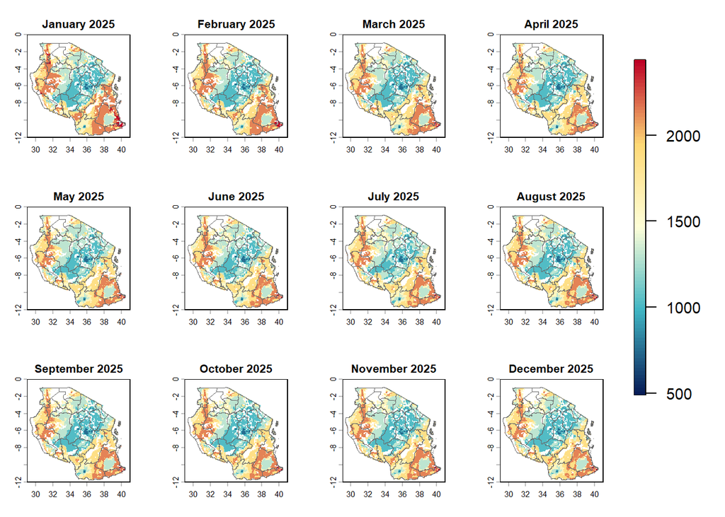

```r
# Define the continuous color palette and reverse it
#color_palette <- colorRampPalette(c("blue", "wheat", "red"))(100)
color_palette <- colorRampPalette(c("#081d58", "#41b6c4", "#ffffd9", "#fed976", "#bd0026"))(100)

# Set up plot layout with an extra row for the legend
layout_matrix <- matrix(c(1, 2, 3, 4, 13,
                          5, 6, 7, 8, 13,
                          9, 10, 11, 12, 13), nrow = 3, byrow = TRUE)

# Set up layout
layout(layout_matrix, heights = c(2, 2, 2, 0.6), widths = c(1, 1, 1, 1, 0.6))


break_interval <- 250

# Loop through each month to plot sorghum prices
par(mar = c(0, 0, 0, 0))
for (i in 1:12) {
  plot(predictions_sorghum[[i]], main = paste(month.name[i], year),
       zlim = c(min_sorghum, max_sorghum), col = color_palette, breaks = seq(min_sorghum, max_sorghum, by = break_interval), legend = FALSE, axes = TRUE, cex.main = 1.0)

  plot(tza1, add = TRUE, border = "dimgray", lwd = 0.1)

  points(training_data, pch = 20, col = "red", cex = 0.5)
}

# Generate pretty breaks for the legend
legend_breaks <- pretty(c(min_sorghum, max_sorghum), n = 5)

# Reset plot layout to 1x1 for the legend
layout(matrix(1))
par(mar = c(5, 4, 2, 4))

# Plot the legend in the bottom row, centered horizontally
image.plot(zlim = c(min_sorghum, max_sorghum), legend.only = TRUE,
           col = color_palette,
           legend.width = 0.7, legend.shrink = 0.9,
           axis.args = list(at = legend_breaks, labels = legend_breaks, cex.axis = 0.9),
           legend.args = list(text = "", side = 1, line = 2, cex = 0.9))
```

```r
output_dir_sorghum <- "C:/H/Tanzania Price data/Datasets/Pred-plots/sorghum"

for (i in 1:length(predictions_sorghum)) {
  month_str <- sprintf("%02d", i)
  output_filename <- paste0("sorghum_price_rf_pred_", month_str, ".tif")
  output_path <- file.path(output_dir_sorghum, output_filename)
  writeRaster(predictions_sorghum[[i]], output_path, overwrite = TRUE)
}
```

### Predicted Bulrush Millet Prices

```r
# bmillet
# Function to predict bmillet prices for a given month
predict_for_bmillet <- function(month) {
  # Get the actual NCPI for this specific month
  current_cpi <- cpi_2025$CPI_val[cpi_2025$Month == month]

  # Load rainfall lag for 2025
  delta_rain.sum.lag <- rstack3[paste0("2025-", sprintf("%02d", month), "-01_rain.sum.lag")]
  names(delta_rain.sum.lag) <- "rain.sum.lag"

  # Prepare the predictor stack
  newstack <- c(rstack, delta_rain.sum.lag)
  watertz_proj <- project(watertz, crs(newstack))
  newstack_masked <- mask(newstack, watertz_proj, inverse = TRUE)

  # Define constant data for prediction
  const_maize <- data.frame(
    maize = 0, rice = 0, sorghum = 0, bmillet = 1, fmillet = 0,
    wheat = 0, beans = 0, potato = 0,
    # Month = factor(month, levels = levels(training_data$Month)),
    Month = as.integer(month),
    Year = 2025,
    CPI = current_cpi
  )

  # Generate prediction
  pred <- predict(newstack_masked, rf, const = const_maize, na.rm = TRUE)
  pred <- mask(pred, tza1)

  return(pred)
}

# Create predictions for all months
predictions_bmillet <- lapply(1:12, predict_for_bmillet)

# Extract pixel values from predictions_bmillet
bmillet_values <- unlist(lapply(predictions_bmillet, values))
min_bmillet <- min(bmillet_values, na.rm = TRUE)
min_bmillet
```

```
## [1] 480.2885
```

```r
max_bmillet <- max(bmillet_values, na.rm = TRUE)
max_bmillet
```

```
## [1] 2734.568
```

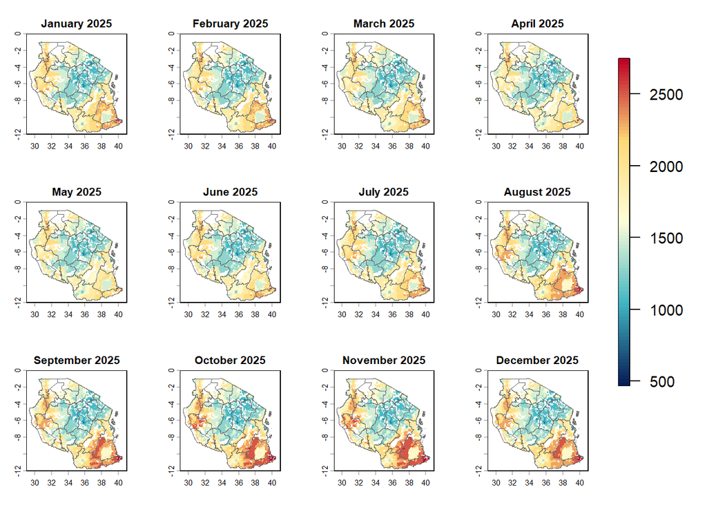

```r
# Define the continuous color palette and reverse it
# color_palette <- rev(terrain.colors(100))
#color_palette <- colorRampPalette(c("blue", "wheat", "red"))(100)
color_palette <- colorRampPalette(c("#081d58", "#41b6c4", "#ffffd9", "#fed976", "#bd0026"))(100)

# Set up plot layout with an extra row for the legend
layout_matrix <- matrix(c(1, 2, 3, 4, 13,
                          5, 6, 7, 8, 13,
                          9, 10, 11, 12, 13), nrow = 3, byrow = TRUE)

# Set up layout
layout(layout_matrix, heights = c(2, 2, 2, 0.6), widths = c(1, 1, 1, 1, 0.6))

# Loop through each month to plot bmillet prices
break_interval <- 200
par(mar = c(0, 0, 0, 0))
for (i in 1:12) {
  plot(predictions_bmillet[[i]], main = paste(month.name[i], year),
       zlim = c(min_bmillet, max_bmillet), col = color_palette,
       breaks = seq(min_bmillet, max_bmillet, by = break_interval),
       legend = FALSE, axes = TRUE, cex.main = 1.0)

  plot(tza1, add = TRUE, border = "dimgray", lwd = 0.1)

  #points(training_data, pch = 20, col = "red", cex = 0.5)
}

# Generate pretty breaks for the legend
legend_breaks <- pretty(c(min_bmillet, max_bmillet), n = 5)

# Reset plot layout to 1x1 for the legend
layout(matrix(1))
par(mar = c(5, 4, 2, 4))

# Plot the legend in the bottom row, centered horizontally
image.plot(zlim = c(min_bmillet, max_bmillet), legend.only = TRUE,
           col = color_palette,
           legend.width = 0.7, legend.shrink = 0.9,
           axis.args = list(at = legend_breaks, labels = legend_breaks, cex.axis = 0.9),
           legend.args = list(text = "", side = 1, line = 2, cex = 0.9))
```

```r
output_dir_bmillet <- "C:/H/Tanzania Price data/Datasets/Pred-plots/bmillet"

for (i in 1:length(predictions_bmillet)) {
  month_str <- sprintf("%02d", i)
  output_filename <- paste0("bmillet_price_rf_pred_", month_str, ".tif")
  output_path <- file.path(output_dir_bmillet, output_filename)
  writeRaster(predictions_bmillet[[i]], output_path, overwrite = TRUE)
}
```

### Predicted Finger Millet Prices

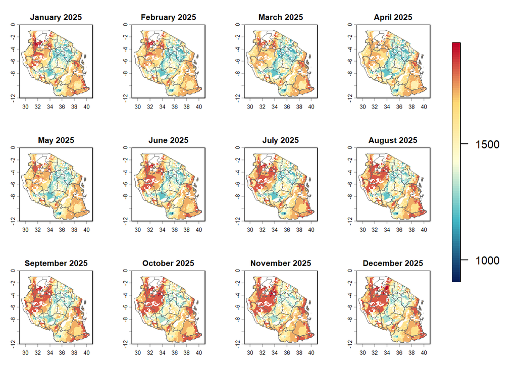

```r
#fmillet
# Function to predict fmillet prices for a given month
predict_for_fmillet <- function(month) {
  # Get the actual NCPI for this specific month
  current_cpi <- cpi_2025$CPI_val[cpi_2025$Month == month]

  # Load rainfall lag for 2025
  delta_rain.sum.lag <- rstack3[paste0("2025-", sprintf("%02d", month), "-01_rain.sum.lag")]
  names(delta_rain.sum.lag) <- "rain.sum.lag"

  # Prepare the predictor stack
  newstack <- c(rstack, delta_rain.sum.lag)
  watertz_proj <- project(watertz, crs(newstack))
  newstack_masked <- mask(newstack, watertz_proj, inverse = TRUE)

  # Define constant data for prediction
  const_maize <- data.frame(
    maize = 0, rice = 0, sorghum = 0, bmillet = 0, fmillet = 1,
    wheat = 0, beans = 0, potato = 0,
    #Month = factor(month, levels = levels(training_data$Month)),
    Month = as.integer(month),
    Year = 2025,
    CPI = current_cpi
  )

  # Generate prediction
  pred <- predict(newstack_masked, rf, const = const_maize, na.rm = TRUE)
  pred <- mask(pred, tza1)

  return(pred)
}

# Create predictions for all months
predictions_fmillet <- lapply(1:12, predict_for_fmillet)

# Extract pixel values from predictions_fmillet
fmillet_values <- unlist(lapply(predictions_fmillet, values))
min_fmillet <- min(fmillet_values, na.rm = TRUE)
max_fmillet <- max(fmillet_values, na.rm = TRUE)

# Define the continuous color palette and reverse it
#color_palette <- rev(terrain.colors(100))
#color_palette <- colorRampPalette(c("blue", "wheat", "red"))(100)
color_palette <- colorRampPalette(c("#081d58", "#41b6c4", "#ffffd9", "#fed976", "#bd0026"))(100)

# Set up plot layout with an extra row for the legend
layout_matrix <- matrix(c(1, 2, 3, 4, 13,
                          5, 6, 7, 8, 13,
                          9, 10, 11, 12, 13), nrow = 3, byrow = TRUE)

# Set up layout
layout(layout_matrix, heights = c(2, 2, 2, 0.6), widths = c(1, 1, 1, 1, 0.6))

# Loop through each month to plot fmillet prices
break_interval <- 100
par(mar = c(0, 0, 0, 0))
for (i in 1:12) {
  plot(predictions_fmillet[[i]], main = paste(month.name[i], year),
       zlim = c(min_fmillet, max_fmillet), col = color_palette,
       breaks = seq(min_fmillet, max_fmillet, by = break_interval),
       legend = FALSE, axes = TRUE, cex.main = 1.0)

  plot(tza1, add = TRUE, border = "dimgray", lwd = 0.1)

  points(training_data, pch = 20, col = "red", cex = 0.5)
}

# Generate pretty breaks for the legend
legend_breaks <- pretty(c(min_fmillet, max_fmillet), n = 3)

# Reset plot layout to 1x1 for the legend
layout(matrix(1))
par(mar = c(5, 4, 2, 4))

# Plot the legend in the bottom row, centered horizontally
image.plot(zlim = c(min_fmillet, max_fmillet), legend.only = TRUE,
           col = color_palette,
           legend.width = 0.7, legend.shrink = 0.9,
           axis.args = list(at = legend_breaks, labels = legend_breaks, cex.axis = 0.9),
           legend.args = list(text = "", side = 1, line = 2, cex = 0.9))
```

```r
output_dir_fmillet <- "C:/H/Tanzania Price data/Datasets/Pred-plots/fmillet"

for (i in 1:length(predictions_fmillet)) {
  month_str <- sprintf("%02d", i)
  output_filename <- paste0("fmillet_price_rf_pred_", month_str, ".tif")
  output_path <- file.path(output_dir_fmillet, output_filename)
  writeRaster(predictions_fmillet[[i]], output_path, overwrite = TRUE)
}
```

### Predicted Wheat Prices

```r
#Wheat
# Function to predict wheat prices for a given month
predict_for_wheat <- function(month) {
  # Get the actual NCPI for this specific month
  current_cpi <- cpi_2025$CPI_val[cpi_2025$Month == month]

  # Load rainfall lag for 2025
  delta_rain.sum.lag <- rstack3[paste0("2025-", sprintf("%02d", month), "-01_rain.sum.lag")]
  names(delta_rain.sum.lag) <- "rain.sum.lag"

  # Prepare the predictor stack
  newstack <- c(rstack, delta_rain.sum.lag)
  watertz_proj <- project(watertz, crs(newstack))
  newstack_masked <- mask(newstack, watertz_proj, inverse = TRUE)

  # Define constant data for prediction
  const_maize <- data.frame(
    maize = 0, rice = 0, sorghum = 0, bmillet = 0, fmillet = 0,
    wheat = 1, beans = 0, potato = 0,
    #Month = factor(month, levels = levels(training_data$Month)),
    Month = as.integer(month),
    Year = 2025,
    CPI = current_cpi
  )

  # Generate prediction
  pred <- predict(newstack_masked, rf, const = const_maize, na.rm = TRUE)
  pred <- mask(pred, tza1)

  return(pred)
}

# Create predictions for all months
predictions_wheat <- lapply(1:12, predict_for_wheat)
# Extract pixel values from predictions_wheat
wheat_values <- unlist(lapply(predictions_wheat, values))
min_wheat <- min(wheat_values, na.rm = TRUE)
min_wheat
```

```
## [1] 709.6993
```

```r
max_wheat <- max(wheat_values, na.rm = TRUE)
max_wheat
```

```
## [1] 3346.314
```

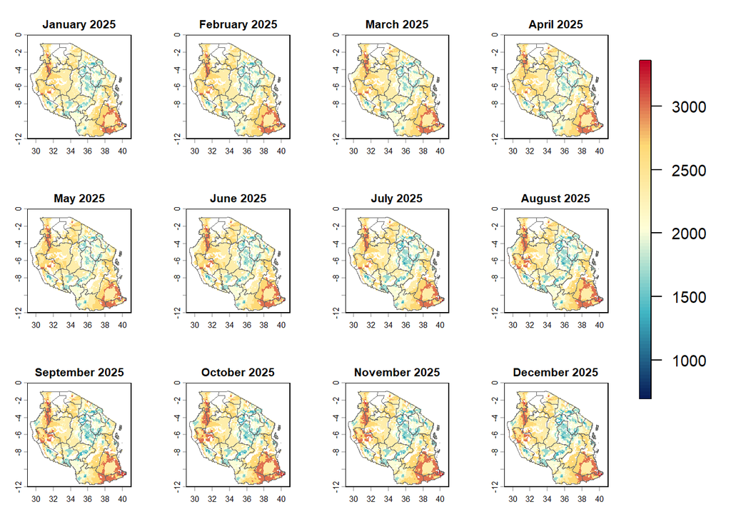

```r
# Define the continuous color palette and reverse it
# color_palette <- rev(terrain.colors(100))
#color_palette <- colorRampPalette(c("blue", "wheat", "red"))(100)
color_palette <- colorRampPalette(c("#081d58", "#41b6c4", "#ffffd9", "#fed976", "#bd0026"))(100)

# Set up plot layout with an extra row for the legend
layout_matrix <- matrix(c(1, 2, 3, 4, 13,
                          5, 6, 7, 8, 13,
                          9, 10, 11, 12, 13), nrow = 3, byrow = TRUE)

# Set up layout
layout(layout_matrix, heights = c(2, 2, 2, 0.6), widths = c(1, 1, 1, 1, 0.6))


# Define the break interval for both plot and legend
break_interval <- 300

# Loop through each month to plot wheat prices
par(mar = c(0, 0, 0, 0))
for (i in 1:12) {
  plot(predictions_wheat[[i]], main = paste(month.name[i], year),
       zlim = c(min_wheat, max_wheat), col = color_palette,
       breaks = seq(min_wheat, max_wheat, by = break_interval),
       legend = FALSE, axes = TRUE, cex.main = 1.0)

  plot(tza1, add = TRUE, border = "dimgray", lwd = 0.1)

  points(training_data, pch = 20, col = "red", cex = 0.5)
}

# Generate pretty breaks for the legend
legend_breaks <- pretty(c(min_wheat, max_wheat), n = 5)

# Reset plot layout to 1x1 for the legend
layout(matrix(1))
par(mar = c(5, 4, 2, 4))

# Plot the legend in the bottom row, centered horizontally
image.plot(zlim = c(min_wheat, max_wheat), legend.only = TRUE,
           col = color_palette,
           legend.width = 0.7, legend.shrink = 0.9,
           axis.args = list(at = legend_breaks, labels = legend_breaks, cex.axis = 0.9),
           legend.args = list(text = "", side = 1, line = 2, cex = 0.9))
```

```r
output_dir_wheat <- "C:/H/Tanzania Price data/Datasets/Pred-plots/wheat"

#save
for (i in 1:length(predictions_wheat)) {
  month_str <- sprintf("%02d", i)
  output_filename <- paste0("wheat_price_rf_pred_", month_str, ".tif")
  output_path <- file.path(output_dir_wheat, output_filename)
  writeRaster(predictions_wheat[[i]], output_path, overwrite = TRUE)
}
```

## Predicted potato prices

```r
#potatoes
# Function to predict potato prices for a given month
predict_for_potato <- function(month) {
  # Get the actual NCPI for this specific month
  current_cpi <- cpi_2025$CPI_val[cpi_2025$Month == month]

  # Load rainfall lag for 2025
  delta_rain.sum.lag <- rstack3[paste0("2025-", sprintf("%02d", month), "-01_rain.sum.lag")]
  names(delta_rain.sum.lag) <- "rain.sum.lag"

  # Prepare the predictor stack
  newstack <- c(rstack, delta_rain.sum.lag)
  watertz_proj <- project(watertz, crs(newstack))
  newstack_masked <- mask(newstack, watertz_proj, inverse = TRUE)

  # Define constant data for prediction
  const_maize <- data.frame(
    maize = 0, rice = 0, sorghum = 0, bmillet = 0, fmillet = 0,
    wheat = 0, beans = 0, potato = 1,
    # Month = factor(month, levels = levels(training_data$Month)),
    Month = as.integer(month),
    Year = 2025,
    CPI = current_cpi
  )

  # Generate prediction
  pred <- predict(newstack_masked, rf, const = const_maize, na.rm = TRUE)
  pred <- mask(pred, tza1)

  return(pred)
}


# Create predictions for all months
predictions_potato <- lapply(1:12, predict_for_potato)

# Extract pixel values from predictions_potato
potato_values <- unlist(lapply(predictions_potato, values))
min_potato <- min(potato_values, na.rm = TRUE)
min_potato
```

```
## [1] 585.0594
```

```r
max_potato <- max(potato_values, na.rm = TRUE)
max_potato
```

```
## [1] 1408.106
```

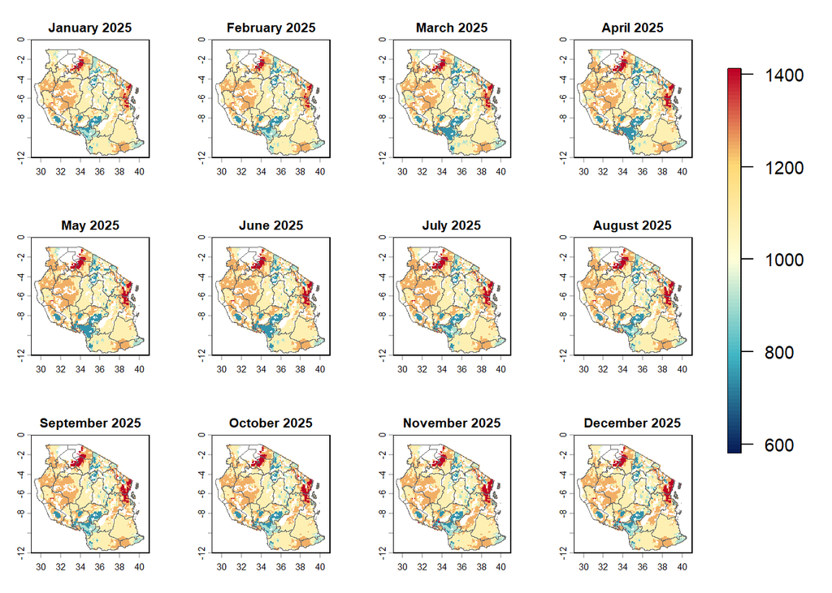

```r
# Define the continuous color palette and reverse it
# color_palette <- rev(terrain.colors(100))
#color_palette <- colorRampPalette(c("blue", "wheat", "red"))(100)
color_palette <- colorRampPalette(c("#081d58", "#41b6c4", "#ffffd9", "#fed976", "#bd0026"))(100)


# Set up plot layout with an extra row for the legend
layout_matrix <- matrix(c(1, 2, 3, 4, 13,
                          5, 6, 7, 8, 13,
                          9, 10, 11, 12, 13), nrow = 3, byrow = TRUE)

# Set up layout
layout(layout_matrix, heights = c(2, 2, 2, 0.6), widths = c(1, 1, 1, 1, 0.6))


# Loop through each month to plot potato prices
break_interval <- 150
par(mar = c(0, 0, 0, 0))
for (i in 1:12) {
  plot(predictions_potato[[i]],  main = paste(month.name[i], year),
       zlim = c(min_potato, max_potato), col = color_palette,
       breaks = seq(min_potato, max_potato, by = break_interval),
       legend = FALSE, axes = TRUE,cex.main = 1.0)

  plot(tza1, add = TRUE, border = "dimgray", lwd = 0.1)

  points(training_data, pch = 20, col = "red", cex = 0.5)
}

# Generate pretty breaks for the legend
legend_breaks <- pretty(c(min_potato, max_potato), n = 5)

# Reset plot layout to 1x1 for the legend
layout(matrix(1))
par(mar = c(5, 4, 2, 4))

# Plot the legend in the bottom row, centered horizontally
image.plot(zlim = c(min_potato, max_potato), legend.only = TRUE,
           col = color_palette,
           legend.width = 0.7, legend.shrink = 0.9,
           axis.args = list(at = legend_breaks, labels = legend_breaks, cex.axis = 0.9),
           legend.args = list(text = "", side = 1, line = 2, cex = 0.9))
```

```r
output_dir_potato <- "C:/H/Tanzania Price data/Datasets/Pred-plots/potato"

#save
for (i in 1:length(predictions_potato)) {
  month_str <- sprintf("%02d", i)
  output_filename <- paste0("potato_price_rf_pred_", month_str, ".tif")
  output_path <- file.path(output_dir_potato, output_filename)
  writeRaster(predictions_potato[[i]], output_path, overwrite = TRUE)
}
```

# Comparing Pooled Vs Crop Specific Price Predictions Using different cross validation methods

## 1. Temporal split validation - Standard RF

```r
# Define the Split
# Training: 2021-2024 | Validation: 2025-2026
# sapply(mypts, class)
training_data <- mypts %>% filter(Year <= 2024) %>% as.data.frame()
validation_data <- mypts %>% filter(Year >= 2025) %>% as.data.frame()

# Hyperparameter Tuning for the Pooled Model

# Note: tuneRF can be slow; we use only the required columns to speed it up
predictors_pooled <- c("maize", "rice", "sorghum", "bmillet", "fmillet", "wheat", "beans", "potato", "Month", "Year", "CPI", "ttport_1", "ttcity_u5", "popdens",
 "bio_3", "bio_6", "bio_9", "bio_12", "bio_18", "rain.sum.lag")

trf <- tuneRF(x = training_data[, predictors_pooled],
              y = training_data$pkg_real,
              stepFactor = 1.5, improve = 0.01, ntreeTry = 500, plot = FALSE, trace = TRUE)
```

```
## mtry = 6  OOB error = 29186.06
## Searching left ...
## mtry = 4     OOB error = 34896
## -0.1956393 0.01
## Searching right ...
## mtry = 9     OOB error = 27351.32
## 0.06286372 0.01
## mtry = 13    OOB error = 27540.61
## -0.006920619 0.01
```

```r
best_mtry <- trf[which.min(trf[, 2]), 1]


# Fit the Pooled Temporal RF
rf_pooled_temp <- randomForest(
  formula = pkg_real ~ .,
  data = training_data[, c("pkg_real", predictors_pooled)],
  mtry = best_mtry,
  ntree = 1000,
  nodesize = 5,
  importance = TRUE)

rf_pooled_temp
```

```
##
## Call:
##  randomForest(formula = pkg_real ~ ., data = training_data[, c("pkg_real",      predictors_pooled)], mtry = best_mtry, ntree = 1000, nodesize = 5,      importance = TRUE)
##                Type of random forest: regression
##                      Number of trees: 1000
## No. of variables tried at each split: 9
##
##           Mean of squared residuals: 27306.79
##                     % Var explained: 94.1
```

```r
# Evaluation Function (Pooled vs. Crop-Specific for standard RF)
evaluate_temporal_models <- function(target_crop) {
  cat("Processing:", target_crop, "\n")

  # Filter crop data
  train_c <- training_data %>% filter(Crop == target_crop)
  valid_c <- validation_data %>% filter(Crop == target_crop)

  # Skip if no data for this crop in validation period
  if(nrow(valid_c) == 0) return(NULL)

  # POOLED MODEL PERFORMANCE
  # Predicting 2025/26 using the model trained on all crops 2021-2024
  pooled_pred <- predict(rf_pooled_temp, newdata = valid_c)

  # CROP-SPECIFIC MODEL
  # Predictors for single crop (exclude all other crop dummies)
  preds_spec <- c("Month", "Year", "CPI", "ttport_1", "ttcity_u5", "popdens",
                  "bio_3", "bio_6", "bio_9", "bio_12", "bio_18", "rain.sum.lag")

  rf_specific <- randomForest(
    pkg_real ~ .,
    data = train_c[, c("pkg_real", preds_spec)],
    ntree = 1000,
    nodesize = 5)

  spec_pred <- predict(rf_specific, newdata = valid_c)

  # PERFOMANCE METRICS
  actual <- valid_c$pkg_real

  res <- data.frame(
    Crop = target_crop,
    RMSE_Pooled = round(sqrt(mean((actual - pooled_pred)^2, na.rm=TRUE)), 2),
    R2_Pooled   = round(cor(actual, pooled_pred)^2, 2),
    RMSE_Specific = round(sqrt(mean((actual - spec_pred)^2, na.rm=TRUE)), 2),
    R2_Specific   = round(cor(actual, spec_pred)^2, 2)
  )
  return(res)
}

# Run Comparison
all_crops <- unique(mypts$Crop)
set.seed(1983)
comparison_results_ts <- do.call(rbind, lapply(all_crops, evaluate_temporal_models))
```

```
## Processing: 1
## Processing: 2
## Processing: 3
## Processing: 4
## Processing: 5
## Processing: 6
## Processing: 7
## Processing: 8
```

```r
print(comparison_results_ts)
```

```
##       Crop RMSE_Pooled R2_Pooled RMSE_Specific R2_Specific
## 1    Maize      201.06      0.23        198.04        0.23
## 2     Rice      340.80      0.24        338.86        0.23
## 3  Sorghum      339.93      0.44        339.45        0.44
## 4 B.Millet      393.73      0.64        395.06        0.63
## 5 F.Millet      703.96      0.19        706.59        0.18
## 6    Wheat      372.85      0.54        376.80        0.53
## 7    Beans      332.69      0.37        332.90        0.37
## 8   Potato      181.73      0.51        180.42        0.52
```

```r
# Clean up the results directly without pivot_wider
comparison_df_wide <- comparison_results_ts %>%
  rename(
    R_squared_Pooled = R2_Pooled,
    R_squared_Crop_Specific = R2_Specific,
    RMSE_Crop_Specific = RMSE_Specific)
```

```r
knitr::kable(comparison_df_wide, caption = "Model Comparison: R² and RMSE (Temporal Validation 2025-2026)")
```

Model Comparison: R² and RMSE (Temporal Validation 2025-2026)

| Crop | RMSE_Pooled | R_squared_Pooled | RMSE_Crop_Specific | R_squared_Crop_Specific |
| --- | --- | --- | --- | --- |
| Maize | 201.06 | 0.23 | 198.04 | 0.23 |
| Rice | 340.80 | 0.24 | 338.86 | 0.23 |
| Sorghum | 339.93 | 0.44 | 339.45 | 0.44 |
| B.Millet | 393.73 | 0.64 | 395.06 | 0.63 |
| F.Millet | 703.96 | 0.19 | 706.59 | 0.18 |
| Wheat | 372.85 | 0.54 | 376.80 | 0.53 |
| Beans | 332.69 | 0.37 | 332.90 | 0.37 |
| Potato | 181.73 | 0.51 | 180.42 | 0.52 |

```r
write.csv(comparison_df_wide, "Temporal-split-results_std_RF.csv", row.names = FALSE)
```

# 2. Autoregressive Random Forest

This approach involves incorporating lagged Prices as predictors to capture temporal dependencies in the data.

```r
mypts <- as.data.frame(mypts) %>%
  arrange(Crop, Market, Year, Month) %>%
  group_by(Crop, Market) %>%
  mutate(pkg_lag1 = lag(pkg_real, 1),
         pkg_lag2 = lag(pkg_real, 2),
         pkg_lag3 = lag(pkg_real, 3)) %>%
  ungroup() %>%
  na.omit()
```

```r
# Training: 2021-2024 | Validation: 2025-2026
training_data <- mypts %>% filter(Year <= 2024)
validation_data <- mypts %>% filter(Year >= 2025)
```

```r
# Hyperparameter Tuning for Pooled AR
predictors_ar <- c("maize", "rice", "sorghum", "bmillet", "fmillet", "wheat", "beans", "potato", "Month", "Year", "CPI", "ttport_1", "ttcity_u5", "popdens",
 "bio_3", "bio_6", "bio_9", "bio_12", "bio_18", "rain.sum.lag", "pkg_lag1", "pkg_lag2", "pkg_lag3")

cat("Tuning Pooled AR Model...\n")
```

```
## Tuning Pooled AR Model...
```

```r
trf_ar <- tuneRF(x = training_data[, predictors_ar], y = training_data$pkg_real,
                 stepFactor = 1.5, improve = 0.01, ntreeTry = 500, plot = FALSE, trace = FALSE)
```

```
## 0.01964191 0.01
## 0.01007028 0.01
## -0.02015378 0.01
## -0.07313499 0.01
```

```r
best_mtry_ar <- trf_ar[which.min(trf_ar[, 2]), 1]

# Fit Final Pooled AR
rf_pooled_ar <- randomForest(pkg_real ~ ., data = training_data[, c("pkg_real", predictors_ar)], mtry = best_mtry_ar, ntree = 1000, importance = TRUE)

rf_pooled_ar
```

```
##
## Call:
##  randomForest(formula = pkg_real ~ ., data = training_data[, c("pkg_real",      predictors_ar)], mtry = best_mtry_ar, ntree = 1000, importance = TRUE)
##                Type of random forest: regression
##                      Number of trees: 1000
## No. of variables tried at each split: 4
##
##           Mean of squared residuals: 31770.1
##                     % Var explained: 93.25
```

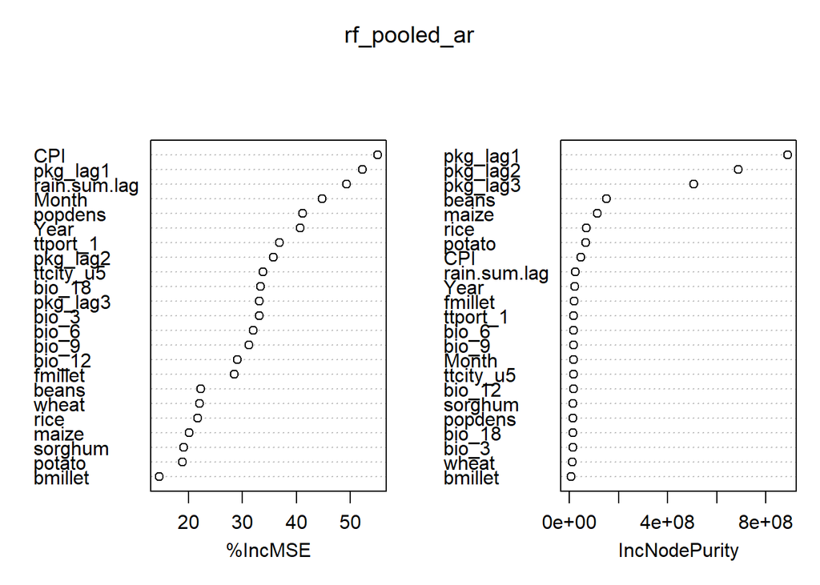

```r
varImpPlot(rf_pooled_ar)
```

```r
# Evaluation Function (Pooled AR vs. Crop-Specific AR)
evaluate_ar_models <- function(target_crop) {
  cat("AR Evaluation for:", target_crop, "\n")

  train_c <- training_data %>% filter(Crop == target_crop)
  valid_c <- validation_data %>% filter(Crop == target_crop)

  if(nrow(valid_c) == 0) return(NULL)

  # Pooled AR Prediction
  pred_pooled <- predict(rf_pooled_ar, newdata = valid_c)

  # Crop-Specific AR Model
  # Exclude crop indicators for specific model
  preds_spec <- c("Month", "Year", "CPI", "ttport_1", "ttcity_u5", "popdens",
                  "bio_3", "bio_6", "bio_9", "bio_12", "bio_18", "rain.sum.lag",
                  "pkg_lag1", "pkg_lag2", "pkg_lag3")

  # Specific mtry tuning for fairness
  trf_spec <- tuneRF(x = train_c[, preds_spec], y = train_c$pkg_real,
                     stepFactor = 1.5, improve = 0.01, ntreeTry = 200, plot = FALSE, trace = FALSE)

mtry_spec <- trf_spec[which.min(trf_spec[, 2]), 1]

rf_spec_ar <- randomForest(pkg_real ~ ., data = train_c[, c("pkg_real", preds_spec)], mtry = mtry_spec, ntree = 1000)

  pred_spec <- predict(rf_spec_ar, newdata = valid_c)

  # Metrics
  actual <- valid_c$pkg_real
  return(data.frame(
    Crop = target_crop,
    RMSE_Pooled_AR = round(sqrt(mean((actual - pred_pooled)^2, na.rm=TRUE)), 2),
    R2_Pooled_AR   = round(cor(actual, pred_pooled)^2, 2),
    RMSE_Spec_AR   = round(sqrt(mean((actual - pred_spec)^2, na.rm=TRUE)), 2),
    R2_Spec_AR     = round(cor(actual, pred_spec)^2, 2)
  ))
}

# Execute and Compare
set.seed(1983)
comparison_ar_final <- do.call(rbind, lapply(unique(mypts$Crop), evaluate_ar_models))
```

```
## AR Evaluation for: 1
## 0.01073357 0.01
## 0.009319475 0.01
## -0.04659281 0.01
## AR Evaluation for: 2
## 0.02840259 0.01
## -0.0009262316 0.01
## -0.06124316 0.01
## AR Evaluation for: 3
## -0.005777284 0.01
## -0.03494154 0.01
## AR Evaluation for: 4
## 0.05186184 0.01
## -0.01945675 0.01
## -0.08264479 0.01
## AR Evaluation for: 5
## 0.004273939 0.01
## -0.01208844 0.01
## AR Evaluation for: 6
## 0.05529602 0.01
## 0.02017113 0.01
## 0.02905516 0.01
## -0.1220922 0.01
## AR Evaluation for: 7
## 0.03832508 0.01
## 0.009833064 0.01
## -0.05692883 0.01
## AR Evaluation for: 8
## 0.01689216 0.01
## 0.0001480481 0.01
## -0.04499869 0.01
```

```r
print(comparison_ar_final)
```

```
##       Crop RMSE_Pooled_AR R2_Pooled_AR RMSE_Spec_AR R2_Spec_AR
## 1    Maize         124.17         0.57       135.70       0.58
## 2     Rice         202.56         0.59       213.72       0.58
## 3  Sorghum         187.00         0.82       241.98       0.71
## 4 B.Millet         173.11         0.93       193.00       0.91
## 5 F.Millet         367.62         0.70       523.83       0.56
## 6    Wheat         284.04         0.73       294.00       0.70
## 7    Beans         208.49         0.75       221.75       0.74
## 8   Potato         132.85         0.70       133.20       0.69
```

```r
comparison_df_wide_ar <- comparison_ar_final %>%
  rename(
    RMSE_Pooled = RMSE_Pooled_AR,
    R_squared_Pooled = R2_Pooled_AR,
    RMSE_Crop_Specific = RMSE_Spec_AR,
    R_squared_Crop_Specific = R2_Spec_AR)
```

```r
knitr::kable(comparison_df_wide_ar, digits = 2, caption = "Table 2: Autoregressive (AR) Model Comparison - Pooled vs. Crop-Specific")
```

Table 2: Autoregressive (AR) Model Comparison - Pooled vs. Crop-Specific

| Crop | RMSE_Pooled | R_squared_Pooled | RMSE_Crop_Specific | R_squared_Crop_Specific |
| --- | --- | --- | --- | --- |
| Maize | 124.17 | 0.57 | 135.70 | 0.58 |
| Rice | 202.56 | 0.59 | 213.72 | 0.58 |
| Sorghum | 187.00 | 0.82 | 241.98 | 0.71 |
| B.Millet | 173.11 | 0.93 | 193.00 | 0.91 |
| F.Millet | 367.62 | 0.70 | 523.83 | 0.56 |
| Wheat | 284.04 | 0.73 | 294.00 | 0.70 |
| Beans | 208.49 | 0.75 | 221.75 | 0.74 |
| Potato | 132.85 | 0.70 | 133.20 | 0.69 |

```r
write.csv(comparison_df_wide_ar, "Temporal-split-results_AR.csv", row.names = FALSE)
```

## 3. Random split validation

Here the dataset is split once (70:30). The model is trained on one part of the data (70%) and evaluated on the remaining set of the data (30%).

```r
# Prepare Pooled Data to Split
mypts <- as.data.frame(mypts)
# sapply(mypts, class)
rows <- sample(x = 1:nrow(mypts), size = 0.70 * nrow(mypts))
train_pooled <- mypts[rows, ]
test_pooled  <- mypts[-rows, ]


# Hyperparameter Tuning for Pooled Model
# Define predictors for pooled (including crop dummies)
predictors_pooled <- c("maize", "rice", "sorghum", "bmillet", "fmillet", "wheat", "beans", "potato", "Month", "Year", "CPI", "ttport_1", "ttcity_u5", "popdens",
"bio_3", "bio_6", "bio_9", "bio_12", "bio_18", "rain.sum.lag")

x_vars_p <- train_pooled[, predictors_pooled]
y_var_p  <- train_pooled$pkg_real

cat("Tuning Pooled Model...\n")
```

```
## Tuning Pooled Model...
```

```r
trf_p <- tuneRF(x = x_vars_p, y = y_var_p, stepFactor = 1.5, improve = 0.01, ntreeTry = 500, plot = FALSE, trace = FALSE)
```

```
## -0.1762552 0.01
## 0.06013946 0.01
## 0.001910389 0.01
```

```r
best_mtry_p <- trf_p[which.min(trf_p[, 2]), 1]

# Fit Final Pooled Model
RF_pooled <- randomForest(pkg_real ~ ., data = train_pooled[, c("pkg_real", predictors_pooled)], mtry = best_mtry_p, ntree = 1000, nodesize = 5, importance = TRUE)

RF_pooled
```

```
##
## Call:
##  randomForest(formula = pkg_real ~ ., data = train_pooled[, c("pkg_real",      predictors_pooled)], mtry = best_mtry_p, ntree = 1000, nodesize = 5,      importance = TRUE)
##                Type of random forest: regression
##                      Number of trees: 1000
## No. of variables tried at each split: 13
##
##           Mean of squared residuals: 34921.41
##                     % Var explained: 92.85
```

```r
# Evaluation Function: Pooled vs. Crop-Specific
evaluate_models <- function(target_crop) {
  cat("Evaluating Crop:", target_crop, "\n")

  # Filter data for this specific crop
  crop_data <- mypts[mypts$Crop == target_crop, ]

  # Split this crop's data 70/30
  set.seed(1983)
  rows_c <- sample(x = 1:nrow(crop_data), size = 0.70 * nrow(crop_data))
  train_c <- crop_data[rows_c, ]
  test_c  <- crop_data[-rows_c, ]

  # POOLED MODEL PERFORMANCE
  # Use the big RF_pooled to predict on this crop's specific test set
  pred_pooled <- predict(RF_pooled, newdata = test_c)

  # CROP-SPECIFIC MODEL
  # Predictors excluding crop dummies (since they are constant for one crop)
  predictors_c <- c("Month", "Year", "CPI", "ttport_1", "ttcity_u5", "popdens",
                    "bio_3", "bio_6", "bio_9", "bio_12", "bio_18","rain.sum.lag")

  # Tune specifically for this crop to be fair
  trf_c <- tuneRF(x = train_c[, predictors_c], y = train_c$pkg_real, stepFactor = 1.5, improve = 0.01, ntreeTry = 500, plot = FALSE, trace = FALSE)

  best_mtry_c <- trf_c[which.min(trf_c[, 2]), 1]
  rf_specific <- randomForest(pkg_real ~ ., data = train_c[, c("pkg_real", predictors_c)],mtry = best_mtry_c, ntree = 1000, nodesize = 5)

  pred_specific <- predict(rf_specific, newdata = test_c)

  # METRICS
  metrics <- data.frame(
    Crop = target_crop,
    RMSE_Pooled = round(sqrt(mean((test_c$pkg_real - pred_pooled)^2, na.rm=TRUE)), 2),
    R2_Pooled   = round(summary(lm(test_c$pkg_real ~ pred_pooled))$r.squared, 2),
    RMSE_Specific = round(sqrt(mean((test_c$pkg_real - pred_specific)^2, na.rm=TRUE)), 2),
    R2_Specific   = round(summary(lm(test_c$pkg_real ~ pred_specific))$r.squared, 2)
  )

  return(metrics)
}
```

```r
# Run and save results
all_crops <- unique(mypts$Crop)
comparison_results_tt <- do.call(rbind, lapply(all_crops, evaluate_models))
```

```
## Evaluating Crop: 1
## -0.0936124 0.01
## 0.04856359 0.01
## 0.005127983 0.01
## Evaluating Crop: 2
## -0.1029928 0.01
## 0.04394681 0.01
## -0.03688437 0.01
## Evaluating Crop: 3
## -0.02377015 0.01
## 0.04034933 0.01
## -0.01640377 0.01
## Evaluating Crop: 4
## -0.03582559 0.01
## -0.02799871 0.01
## Evaluating Crop: 5
## -0.03113707 0.01
## -0.006846908 0.01
## Evaluating Crop: 6
## -0.05838032 0.01
## 0.002921601 0.01
## Evaluating Crop: 7
## -0.08313875 0.01
## 0.02743352 0.01
## 0.003001993 0.01
## Evaluating Crop: 8
## -0.02621305 0.01
## 0.01818056 0.01
## -0.001453224 0.01
```

```r
print(comparison_results_tt)
```

```
##       Crop RMSE_Pooled R2_Pooled RMSE_Specific R2_Specific
## 1    Maize       96.13      0.82        117.73        0.74
## 2     Rice      125.02      0.93        178.19        0.85
## 3  Sorghum      144.32      0.88        221.49        0.71
## 4 B.Millet      106.80      0.96        206.40        0.83
## 5 F.Millet      161.36      0.88        225.09        0.75
## 6    Wheat      179.96      0.88        282.50        0.68
## 7    Beans      143.24      0.90        201.28        0.80
## 8   Potato       92.41      0.81        116.04        0.70
```

```r
comparison_df_wide3 <- comparison_results_tt %>%
  rename(
    RMSE_Pooled = RMSE_Pooled,
    R_squared_Pooled = R2_Pooled,
    RMSE_Crop_Specific = RMSE_Specific,
    R_squared_Crop_Specific = R2_Specific)
```

```r
knitr::kable(comparison_df_wide3, digits = 2, caption = "Table 3: Model Comparison (70/30 Train-Test Split Validation)")
```

Table 3: Model Comparison (70/30 Train-Test Split Validation)

| Crop | RMSE_Pooled | R_squared_Pooled | RMSE_Crop_Specific | R_squared_Crop_Specific |
| --- | --- | --- | --- | --- |
| Maize | 96.13 | 0.82 | 117.73 | 0.74 |
| Rice | 125.02 | 0.93 | 178.19 | 0.85 |
| Sorghum | 144.32 | 0.88 | 221.49 | 0.71 |
| B.Millet | 106.80 | 0.96 | 206.40 | 0.83 |
| F.Millet | 161.36 | 0.88 | 225.09 | 0.75 |
| Wheat | 179.96 | 0.88 | 282.50 | 0.68 |
| Beans | 143.24 | 0.90 | 201.28 | 0.80 |
| Potato | 92.41 | 0.81 | 116.04 | 0.70 |

```r
write.csv(comparison_df_wide3, "Train-Test-Validation-results.csv", row.names = FALSE)
```

# Comparison of regional and predicted rural maize prices

```r
# Comparison of regional and predicted rural maize prices
mypts_df <- as.data.frame(mypts) %>%
  filter(Year == 2025, Crop == "Maize") %>%
  # Explicitly use dplyr::select to avoid conflicts with terra
  dplyr::select(Region_GADM, Month, pkg_real)
```

```r
comparison_list <- list()

# Comparison loop
for (m in 1:12) {
  message("Processing month: ", m)

  # Load Prediction Raster
  pred_file <- sprintf("C:/H/Tanzania Price data/Datasets/Pred-plots/Maize/maize_price_rf_pred_%02d.tif", m)

  if (!file.exists(pred_file)) next

  pred_maize <- rast(pred_file) |> project(crs(tza1))
  names(pred_maize) <- "Predicted"

  # Calculate Regional Benchmark using pkg_real
  dta_reg <- mypts_df %>%
    filter(Month == m) %>%
    group_by(Region_GADM) %>%
    summarise(Reg_max_pkg = max(pkg_real, na.rm = TRUE)) %>%
    ungroup()

  # Apply Njombe patch
  if("Iringa" %in% dta_reg$Region_GADM & !"Njombe" %in% dta_reg$Region_GADM){
    iringa_val <- dta_reg$Reg_max_pkg[dta_reg$Region_GADM == "Iringa"]
    dta_reg <- bind_rows(dta_reg, tibble(Region_GADM = "Njombe", Reg_max_pkg = iringa_val))
  }

  # Spatial Join to Raster
  tza1_with_reg <- merge(tza1, dta_reg, by.x = "NAME_1", by.y = "Region_GADM", all.x = TRUE)
  regional_raster <- rasterize(tza1_with_reg, pred_maize, field = "Reg_max_pkg")

  # Data Extraction
  # Convert raster to dataframe and extract regional values
  tmp_df <- as.data.frame(pred_maize, xy = TRUE, na.rm = TRUE)

  # Get regional max values for each pixel coordinate
  reg_vals <- terra::extract(regional_raster, tmp_df[,c("x","y")])
  tmp_df$Regional_Max <- reg_vals[,2] # Extract the second column (the values)

  # Calculate Difference
  tmp_df <- tmp_df %>%
    mutate(
      Diff = Regional_Max - Predicted,
      Month = m
    )

  # Attach Region Names for the X-axis
  pts_tmp <- vect(tmp_df, geom = c("x", "y"), crs = crs(tza1))
  tmp_df$Region <- terra::extract(tza1["NAME_1"], pts_tmp)[,2]

  comparison_list[[m]] <- tmp_df
}
```

```
## Processing month: 1
```

```
## Processing month: 2
```

```
## Processing month: 3
```

```
## Processing month: 4
```

```
## Processing month: 5
```

```
## Processing month: 6
```

```
## Processing month: 7
```

```
## Processing month: 8
```

```
## Processing month: 9
```

```
## Processing month: 10
```

```
## Processing month: 11
```

```
## Processing month: 12
```

```r
comparison_all <- bind_rows(comparison_list) %>%
  filter(!is.na(Region), !is.na(Diff))

comparison_all$Month_Label <- factor(comparison_all$Month, levels = 1:12, labels = month.name)
```

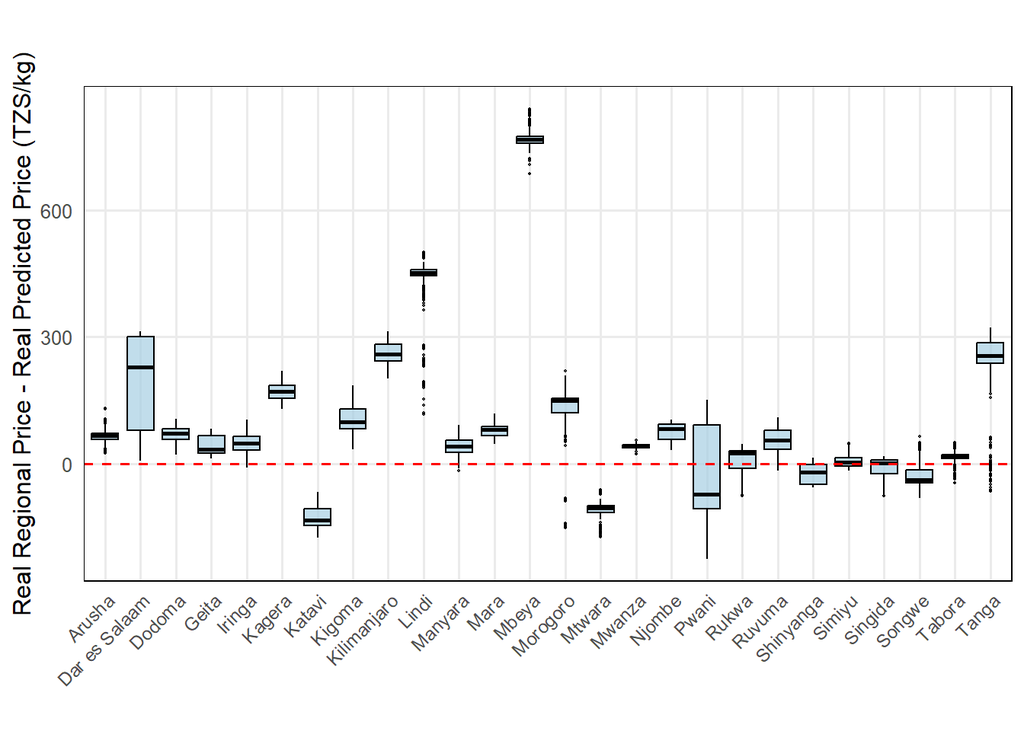

```r
# Filter specifically for January
january_comparison <- comparison_all %>%
  filter(Month == 1)

#png("C:/H/Tanzania Price data/Datasets/figures_and_maps/Figure_9_January_Regional_Comparison.png", width = 2400, height = 1600, res = 300)

ggplot(january_comparison, aes(x = Region, y = Diff)) +
  geom_boxplot(fill = "#A6CEE3", color = "black", outlier.size = 0.3, alpha = 0.7, size = 0.5) +
  geom_hline(yintercept = 0, linetype = "dashed", color = "red", linewidth = 0.6) +
  # Note: facet_wrap is removed to focus on the single month
  labs(
    x = "",
    y = "Real Regional Price - Real Predicted Price (TZS/kg)",
    title = "",
    subtitle = ""
  ) +
  theme_minimal(base_size = 12) +
  theme(
    axis.text.x = element_text(angle = 45, vjust = 1, hjust = 1, size = 9), # Tilted for better readability
    panel.grid.minor = element_blank(),
    panel.border = element_rect(color = "black", fill = NA, linewidth = 0.5)
  )
```

```r
# dev.off()
```

## Prediction Evaluation

### Using 2025/2026 Validation data

```r
pred<-predict(object=rf, newdata=validation_data)
actual<-validation_data$pkg_real
result<-data.frame(actual=actual, predicted=pred)
```

```r
mse <- mean((actual - pred)^2, na.rm=TRUE)
paste('Mean Squared Error:', mse)
```

```
## [1] "Mean Squared Error: 148540.058867605"
```

```r
rmse <- sqrt(mse)
paste('Root Mean Squared error: ',mean(sqrt(rf$mse)))
```

```
## [1] "Root Mean Squared error:  167.446361097807"
```

```r
#Save predicted & observed price
write.csv(result, "result.csv")
```

```r
#reading result.csv file (predicted vs observed)
rslt <- read.csv("result.csv", header=T)
print(names(rslt))
```

```
## [1] "X"         "actual"    "predicted"
```

```r
#RMSE predicting from rf - predicited vs observed
rf.rmse<-round(sqrt(mean( (rslt$actual-rslt$predicted)^2 , na.rm = TRUE )),2)
print(rf.rmse)
```

```
## [1] 385.41
```

```r
#R-square
rf.r2<-round(summary(lm(actual~predicted, rslt))$r.squared,2)
print(rf.r2)
```

```
## [1] 0.73
```

```r
range(actual)
```

```
## [1]  290.3126 3545.8025
```

```r
range(pred)
```

```
## [1]  388.9258 3360.8593
```

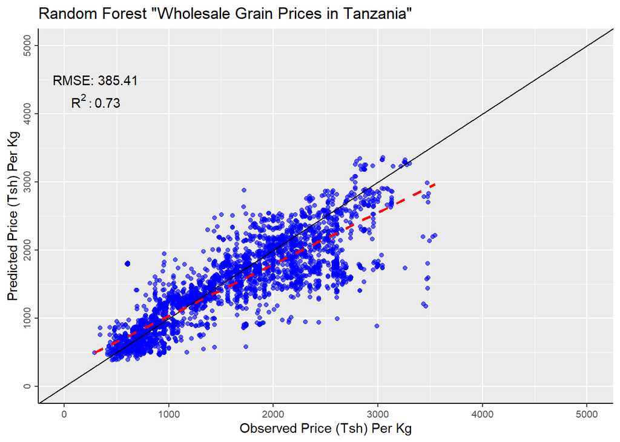

```r
#plotting predicted Vs observed
ggplot(result, aes(x=actual, y=predicted), alpha=0.6) +
  geom_point(colour = "blue", size = 1.4, alpha=0.6) +
  ggtitle('Random Forest "Wholesale Grain Prices in Tanzania"') +
  scale_x_continuous("Observed Price (Tsh) Per Kg",
                     limits = c(0, 5000),
                     breaks = seq(0, 5000, 1000)) +
  scale_y_continuous("Predicted Price (Tsh) Per Kg",
                     limits = c(0, 5000),
                     breaks = seq(0, 5000, 1000)) +
  theme(axis.line = element_line(colour = "black"),
        axis.text.y = element_text(size = 8, angle = 90, hjust = 0.5, vjust = 1),
        axis.text.x = element_text(size = 8)) +
  geom_abline(intercept = 0, slope = 1, linewidth = 0.5) +
  geom_smooth(aes(x = actual, y = predicted), formula = y ~ x, method = "lm", se = FALSE, colour = "red", linetype = 2, size = 0.9) +
  annotate("text", x = 300, y = 4500, label = paste("RMSE:", rf.rmse)) +
  annotate("text", x = 300, y = 4200, label = paste("R^2: ", rf.r2), parse = TRUE)
```

# Partial dependence plots

```r
library(caret)

var_importance <- varImp(rf)

impvar <- rownames(var_importance)[order(var_importance[, 1], decreasing=TRUE)]
```

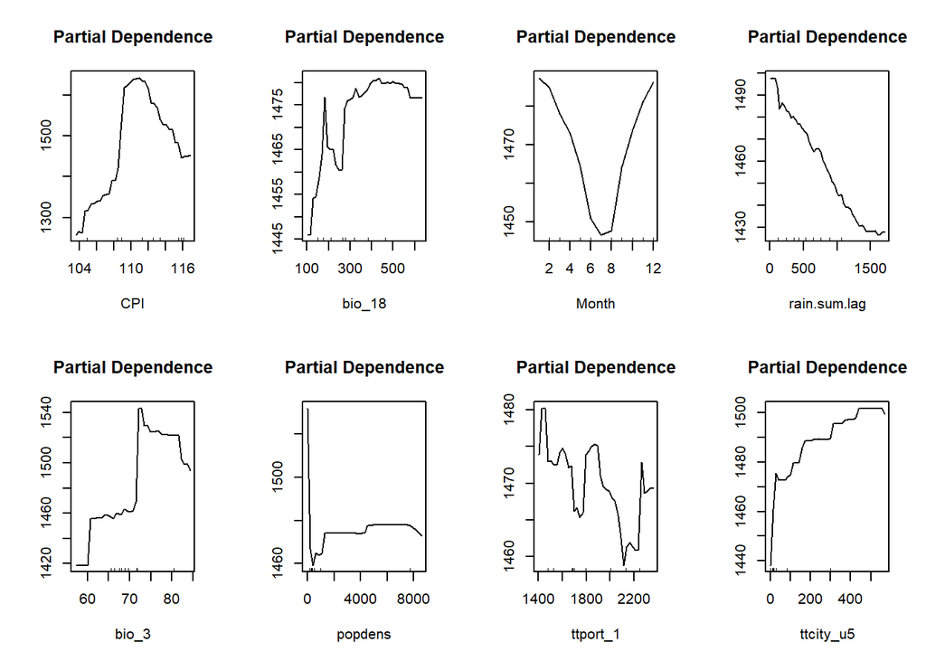

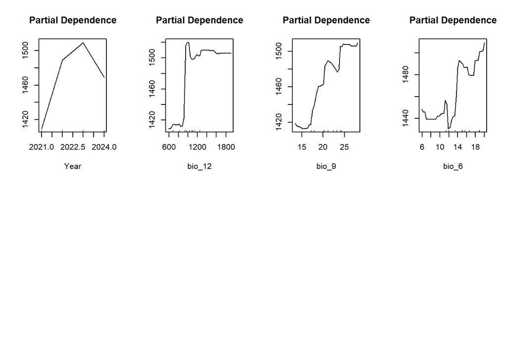

```r
op <- par(mfrow=c(2, 4))
# exclude crop commodities and months
predictors_to_plot <- setdiff(impvar, c("maize", "rice", "sorghum", "bmillet", "fmillet", "wheat", "beans", "potato", "jan", "feb", "mar", "apr", "may", "jun", "jul", "aug", "sep", "oct", "nov", "dec"))

for (i in seq_along(predictors_to_plot)) {
  partialPlot(rf, as.data.frame(training_data), predictors_to_plot[i], xlab=predictors_to_plot[i],
              main="Partial Dependence")
}
```

Some descriptive statistics for each crop

```r
# Compute descriptive statistics for each crop
stats <- prices.monthly.long %>%
  filter(pkg_real > 0) %>%
  group_by(Crop) %>%
  summarise(
    Mean = mean(pkg_real, na.rm = TRUE),
    Median = median(pkg_real, na.rm = TRUE),
    Minimum = min(pkg_real, na.rm = TRUE),
    Maximum = max(pkg_real, na.rm = TRUE),
    Std_Dev = sd(pkg_real, na.rm = TRUE),
    IQR = IQR(pkg_real, na.rm = TRUE),
    Observations = n()
  ) %>%
  arrange(Crop)

print(stats)
```

```
## # A tibble: 8 × 8
##   Crop      Mean Median Minimum Maximum Std_Dev   IQR Observations
##   <fct>    <dbl>  <dbl>   <dbl>   <dbl>   <dbl> <dbl>        <int>
## 1 Maize     725.   691.    275.   1739.    227.  340.         1398
## 2 Rice     2078.  2080.    749.   3465.    450.  608.         1414
## 3 Sorghum  1226.  1206.    290.   2969.    427.  612.         1209
## 4 B.Millet 1332.  1189.    381.   3608.    556.  751.         1017
## 5 F.Millet 1714.  1695.    624.   3261.    471.  487.         1246
## 6 Wheat    1679.  1660.    341.   3594.    499.  564.          973
## 7 Beans    2301.  2306.    950    3621.    469.  730.         1405
## 8 Potato    818.   802.    300.   1613.    218.  228.         1365
```